# Examen 1, versión B. Regresión lineal simple

19 de noviembre de 2021

#### Índice

Pregunta 1 teórica

Pregunta 2 teórica

Pregunta 3 teórica

Pregunta 4 teórica

Pregunta 5 práctica

Pregunta 6 práctica

Pregunta 7 práctica

Usar una confianza de 95% o una significancia de .05 en los casos en donde no se requiera otro nivel de forma explícita. En el caso de realizar alguna transformación de las variables, se tiene que hacer explícita la variable que se usa y la interpretación en las pruebas de hipótesis o intervalos de confianza.

### 1. Regresión a través del origen.

Ocasionalmente, un modelo en donde el valor del intercepto es conocido a priori y es igual a cero puede ser apropiado. Este modelo está dado por:

$$y_{i}=\beta x_{i}+\varepsilon_{i}, \qquad i=1,...,n,$$

donde $\varepsilon_1, \varepsilon_2, ..., \varepsilon_n$ son variables independientes tal que $\varepsilon_i \sim N(0, \sigma^2) \;\; \forall \; \; i= 1,...,n.$

En general $\sigma^2$ es desconocida, pero en lo que sigue suponga que es conocida.

1. Encuentre el estimador de $\beta$ obtenido por el método de máxima verosimilitud, $\widehat{\beta}$.
2. Encuentre la expresión de la varianza de $\widehat{\beta}$.
3. Demuestre que $\widehat{\beta}$ es el UMVUE de $\beta$, es decir, que es el mejor estimador insesgado de $\beta$.

#### Demostración:

Consideremos inicialmente que

$$y_{i}=\beta x_{i}+\varepsilon_{i}, \qquad i=1,...,n$$
donde $\varepsilon_1, \varepsilon_2, ..., \varepsilon_n$ son variables independientes tal que $\varepsilon_i \sim N(0, \sigma^2) \;\; \forall \; \; i= 1,...,n.$ Asumimos $\sigma$ conocido.

Por lo que $y_{i} \sim N(\beta x_{i}, \sigma^2)$

*i) Encuentre el estimador de* $\beta$ *obtenido por el método de máxima verosimilitud,* $\widehat{\beta}$.

La función de verosimilitud es:

$$\begin{align*}
L(\beta, \sigma, y_{1}, ..., y_{n}) &= f(y_1,...,y_{n}, \beta, \sigma^2) \\
&=\prod_{i=1}^{n} f_{i} (y_{i}, \beta \sigma^2) \\
&=\prod_{i=1}^{n} \dfrac{ 1 }{ \sqrt[2]{2 \pi \sigma^2} } e^{-(\dfrac{1}{2 \sigma^2})(y_{i} - \beta x_{i} )^2} \\
&=\dfrac{1}{(2 \pi \sigma^2)^{\dfrac{n}{2}}} e^{-(\dfrac{1}{2 \sigma^2})(\sum_{i=1}^{n}(y_{i} - \beta x_{i})^2)}\\
\end{align*}$$

Por lo que la función de logverosimilitud será:

$$\begin{align*}
ln(L) &= -\dfrac{n}{2}ln(2 \pi \sigma^2) -\dfrac{1}{2 \sigma^2} \sum_{i=1}^n(y_{i} - \beta x_{i})^2\\
\\
\Rightarrow \dfrac{\delta ln(L)}{\delta \beta} &= \dfrac{\delta}{\delta \beta}(-\dfrac{n}{2}ln(2 \pi \sigma^2)-\dfrac{1}{2 \sigma^2} \sum_{i=1}^n(y_i - \beta x_i)^2 ) \\
&= \dfrac{\delta}{\delta \beta}( -\dfrac{n}{2} ln(2 \pi \sigma^2) ) - \dfrac{\delta}{\delta \beta}(\dfrac{1}{2 \sigma^2} \sum_{i=1}^n(y_i - \beta x_i)^2 )\\
&= 0 - \dfrac{1}{2 \sigma^2} \dfrac{\delta}{\delta \beta} \sum_{i=1}^n(y_i - \beta x_i)^2\\
&= -\dfrac{1}{2 \sigma^2}(2) \sum_{i=1}^n(y_i - \beta x_i)(-x_i) \\
&= \dfrac{1}{\sigma^2} \sum_{i=1}^n(y_i - \beta x_i)(x_i)
\end{align*}$$

Igualando a cero:

$$\begin{align*}
&\dfrac{\delta ln(L)}{d \beta} = 0\\
&\Rightarrow \dfrac{1}{\sigma^2} \sum_{i=1}^n(y_i - \beta x_i)(x_i) = 0\\
&\Rightarrow \sum_{i=1}^n(y_i x_i - \beta x_{i}^2 = 0)\\
&\Rightarrow \sum_{i=1}^ny_i x_i - \sum_{i=1}^n \beta x_{i}^2 = 0\\
&\Rightarrow \beta \sum_{i=1}^nx_{i}^2 = \sum_{i=1}^ny_i x_i\\
&\Rightarrow \beta = \dfrac{\sum_{i=1}^ny_i x_i}{\sum_{i=1}^nx_{i}^2}
\end{align*}$$
$\therefore$ El estimador máximo verosimil es:
$$\widehat{\beta} = \dfrac{\sum_{i=1}^ny_i x_i}{\sum_{i=1}^nx_{i}^2}$$

*ii) Encuentre la expresión de la varianza de* $\widehat{\beta}$.

Tomemos $S_{x} = \sum_{i=1}^n x_i^2$
$$\begin{alignat}{4} \Rightarrow \widehat{\beta} = \sum_{i=1}^n \dfrac{x_i}{S_x} y_i
\end{alignat}$$

Sea $k_i = \dfrac{x_i}{S_x}$

$$\begin{align*}
\Rightarrow \widehat{\beta} &= \sum_{i=1}^n k_i y_i\\
\Rightarrow Var[\widehat{\beta}] &= Cov(\widehat{\beta}, \widehat{\beta})\\
&=Cov( \sum_{i=1}^n k_i y_i, \sum_{i=1}^n k_i y_i)\\
&= \sum_{i=1}^n k_i^2 Cov(y_i, y_i) = \sum_{i=1}^n k_i^2 Var[y_i]\\
&= \sum_{i=1}^n k_i^2 \sigma^2 =\sigma^2 \sum_{i=1}^n k_i^2 = \sigma^2 \sum_{i=1}^n (\dfrac{x_i}{S_x})^2\\
&= \sigma^2 \sum_{i=1}^n \dfrac{x_{i}^2}{S_{x}^2} = \dfrac{\sigma^2}{S_{x}^2} \sum_{i=1}^n x_{i}^2 = \dfrac{\sigma^2 \sum_{i=1}^n x_{i}^2}{(\sum_{i=1}^n x_{i}^2)^2}\\
&= \dfrac{\sigma^2}{\sum_{i=1}^n x_{i}^2}
\end{align*}$$

$$\therefore Var[\widehat{\beta}] = \dfrac{\sigma^2}{\sum_{i=1}^n x_{i}^2}$$

*iii) Demuestre que* $\widehat{\beta}$ *es el UMVUE de* $\beta$, *es decir, que es el mejor estimador insesgado de* $\beta$.

Primero probemos que $\widehat{\beta}$ es insesgado:

$$\begin{align*}
E[\widehat{\beta}] &=E[\sum_{i=1}^n k_i y_i]\\
&= \sum_{i=1}^nk_i E[y_i] = \sum_{i=1}^n k_i (\beta x_i) \\
&= \dfrac{\sum_{i=1}^n x_{i}^2 \beta}{\sum_{i=1}^n x_{i}^2} = \beta
\end{align*}$$

$$\therefore \quad\text{Es insesgado}$$

Para continuar queremos poder usar el teorema de Lehmann-Scheffe por lo que veremos a continuacion que $f(y_1 ,\dotsc, y_n;\beta, \sigma^2)$ pertenece a la familia exponencial. Tomemos $y=(y_1 ,\dotsc, y_n)$ y $\gamma=(\beta, \sigma^2)$

$$\begin{align}
& f(y_1 ,\dotsc, y_n;\beta, \sigma^2)\\
&= \dfrac{1}{(2 \pi \sigma^2)^{n/2}}exp\{-\dfrac{1}{2\sigma^2}\sum_{i=1}^n (y_i - \beta x_i)^2 \underbrace{\prod_{i=1}^n \upharpoonleft}_{b(y)}\} \\
&= \dfrac{1}{(2 \pi \sigma^2)^{n/2}}exp\{-\dfrac{1}{2\sigma^2}\sum_{i=1}^n (y_{i}^2-2y_i \beta x_i + \beta^2x_{i}^2)\}b(y)\\
&= \dfrac{1}{(2 \pi \sigma^2)^{n/2}}exp\{-\dfrac{1}{2\sigma^2}\sum_{i=1}^n y_{i}^2 -2\beta \sum_{i=1}^n y_i x_i + \beta^2\sum_{i=1}^n x_{i}^2\} b(y)\\
&= exp\{ -\dfrac{1}{2\sigma^2}(\sum_{i=1}^n y_{i}^2 - 2\beta \sum_{i=1}^n y_i x_i)\} \underbrace{ \dfrac{1}{(2\pi \sigma^2)^{n/2}}exp\{ -\dfrac{1}{2\sigma^2}\beta^2 \sum_{i=1}^n x_{i}^2 \}}_{a(\gamma)} b(y)\\
&= exp\{ -\dfrac{1}{2\sigma^2}\sum_{i=1}^n y_{i}^2 + \dfrac{\beta}{\sigma^2}\sum_{i=1}^n y_i x_i \} a(\gamma)b(y)
\end{align}$$

Entonces tenemos:

- $a(\gamma) = \dfrac{1}{(2 \pi \sigma^2)^{n/2}} exp\{ -\dfrac{\beta^2}{2\sigma^2} \sum_{i=1}^nx_{i}^2 \}$
- $b(y) = \prod_{i=1}^n\upharpoonleft \quad (y_i \in \mathbb{R})$
- $c_1(\gamma)= \dfrac{-1}{2 \sigma^2}$
- $c_2(\gamma) = \dfrac{\beta}{\sigma^2}$
- $d_1(y) = \sum_{i=1}^n y_{i}^2$
- $d_2(y) = \sum_{i=1}^n y_i x_i$

$$\therefore \quad\text{Pertenece a la familia exponencial}$$
Además por resultado 1.7 de las notas de clase sabemos que:

$$T(y_1, \dotsc, y_n)= (\sum_{i=1}^n y_{i}^2, \sum_{i=1}^n y_i x_i)$$
es una estadistica completa y suficiente para $\gamma$

$$\therefore \widehat{\beta} \quad\text{Es el UMVUE de} \quad \beta$$

### 2.

Considere el modelo de regresión
$$y_i=\beta_0 +
\beta_1 x_i + \varepsilon_i,$$

donde $E(\varepsilon_i)=0, \; V(\varepsilon_i)=\sigma^2 \;\; \text{y} \;\; Cov(\varepsilon_i, \varepsilon_j)=0 \; \forall \; i\neq j; \; \; i,j = 1,...,n$.

Calcular $Cov(e_i, \widehat{\beta}_0)$, donde $e_i=y_i-\widehat{y}_i$ y $\widehat{y}_i=\widehat{\beta}_0+\widehat{\beta}_1x_i$, con $\widehat{\beta}_0$ y $\widehat{\beta}_1$ los estimadores de los parámetros del modelo.

Hint: Recordar que $\widehat{y}_i$, $\widehat{\beta}_0$ y $\widehat{\beta}_1$ se pueden escribir como una combinación lineal de las $y_{i's}$.

#### Demostración:

$$\begin{align*}
Cov(e_i, \widehat{\beta_0})&= \mathbb{E}[(e_i)(\widehat{\beta_0})] - \mathbb{E}[e_i]\mathbb{E}[\beta_0] \\
&=\mathbb{E}[(y_i - \widehat{\beta}_0 - \widehat{\beta}_1 x_i)(\widehat{\beta}_0)] - \mathbb{E}[y_i - \widehat{\beta}_0 - \widehat{\beta}_1 x_i] \mathbb{E}[\widehat{\beta}_0]\\
&=\mathbb{E}[y_i \widehat{\beta}_0 - \widehat{\beta}_{0}^2 - \widehat{\beta}_1 \widehat{\beta}_0 x_i] - (\mathbb{E}[y_i] - \mathbb{E}[\widehat{\beta}_0] - \mathbb{E}[\widehat{\beta}_1 x_i])(\mathbb{E}[\widehat{\beta}_0])\\
&=\mathbb{E}[y_i \widehat{\beta}_0] - \mathbb{E}[\widehat{\beta}_{0}^2] - \mathbb{E}[\widehat{\beta}_1 \widehat{\beta}_0 x_i] -\mathbb{E}[y_i]\mathbb{E}[\widehat{\beta}_0] + \mathbb{E}[\widehat{\beta}_0]^2 + \mathbb{E}[\widehat{\beta}_1 x_i]\mathbb{E}[\widehat{\beta}_0]\\
&=cov(y_i, \widehat{\beta}_0) - Var(\widehat{\beta}_0) - cov(\widehat{\beta}_1 x_i, \widehat{\beta}_0)\\
&=cov(y_i, \widehat{\beta}_0) - Var(\widehat{\beta}_0) - x_icov(\widehat{\beta}_1, \widehat{\beta}_0)
\end{align*}$$

Por lo visto en clase en el Resultado 1.3, sabemos que:

- $Var(\widehat{\beta}_0) = \sigma^2 \dfrac{\sum_{i=1}^n x_{i}^2}{nSS_x}$
- $cov(\widehat{\beta}_1, \widehat{\beta}_0) = \dfrac{-\bar{X} \sigma^2}{SS_x}$

Por lo que solo nos queda calcular $cov(y_i, \widehat{\beta}_0)$

$$\begin{align*}
cov(y_i, \widehat{\beta}_0) &= cov(y_i, \sum_{j=1}^n k_{j0} y_j ) \quad \text{Sea } k_{j0} = \dfrac{1}{n}-\dfrac{\bar{X}(x_i-\bar{X})}{SS_x} \\
&= \sum_{j=1}^n k_{j0} cov(y_i, y_j) \quad (como \; Cov(\varepsilon_i, \varepsilon_j)=0 \; \forall \; i\neq j; \; \; i,j = 1,...,n \Rightarrow Cov(y_i, y_j)=0 \; \forall \; i\neq j; \; \; i,j = 1,...,n )\\
&= k_{i0} cov(y_i,y_i) = k_{i0} var(y_i) = (\dfrac{1}{n}-\dfrac{\bar{X}(x_i-\bar{X})}{SS_x}) (\sigma^2)
\end{align*}$$

$$\begin{align*}
\therefore Cov(e_i, \widehat{\beta_0}) &= (\dfrac{1}{n}-\dfrac{\bar{X}(x_i-\bar{X})}{SS_x}) (\sigma^2) - \sigma^2 \dfrac{\sum_{i=1}^n x_{i}^2}{nSS_x} - (x_i)\dfrac{-\bar{X} \sigma^2}{SS_x})\\
&= \sigma^2(\dfrac{SS_x}{nSS_x}-\dfrac{\bar{X}(x_i-\bar{X})}{SS_x} - \dfrac{\sum_{i=1}^n x_{i}^2}{nSS_x}-\dfrac{-\bar{X}x_i}{SS_x})\\
&=\sigma^2( \dfrac{\sum_{i=1}^n (x_i - \bar{X})^2 - \sum_{i=1}^n x_{i}^2}{nSS_x} + \dfrac{\bar{X}x_i - \bar{X}x_i + \bar{X}^2}{SS_x} )\\
&=\sigma^2( \dfrac{\sum_{i=1}^n x_{i}^2 - 2x_i\bar{X} + \bar{X}^2 - \sum_{i=1}^n x_{i}^2}{nSS_x} + \dfrac{\bar{X}^2}{SS_x})\\
&=\sigma^2(\dfrac{\sum_{i=1}^n x_{i}^2 - 2\bar{X} \sum_{i=1}^n x_i + \bar{X}^2 \sum_{i=1}^n 1 -\sum_{i=1}^n x_{i}^2 }{nSS_x} + \dfrac{\bar{X}^2}{SS_x} )\\
&=\sigma^2( (\dfrac{-2\bar{X}}{SS_x})(\dfrac{\sum_{i=1}^n x_i}{n}) + \dfrac{n\bar{X}^2}{nSS_x} + \dfrac{\bar{X}^2}{SS_x} )\\
&=\sigma^2( \bar{X}(\dfrac{-2\bar{X}}{SS_x}) + \dfrac{\bar{X}^2}{SS_x} + \dfrac{\bar{X}^2}{SS_x} )\\
&=\sigma^2(\dfrac{-2\bar{X}^2 + \bar{X}^2 + \bar{X}^2}{SS_x})\\
&=\sigma^2(0) = 0
\end{align*}$$

### 3. Problema Anova. Equivalencia con la prueba t para comparar dos poblaciones.

Sea $X_{1},...,X_{n}$ una m.a. de la distribución $N(\mu_x,\sigma^2)$ y $Y_{1},...,Y_{m}$ una m.a. de la distribución $N(\mu_y,\sigma^2)$, ambas muestras aleatorias son independientes entre sí. La prueba t se usa bajo este contexto para contrastar, por ejemplo:

$$H_0: \mu_x=\mu_y \quad \quad vs \quad \quad H_a: \mu_x \neq \mu_y.$$
Sea $t$ la estadística asociada a la prueba t antes mencionada.

1. Considere una variable $Z$ tal que $Z=1$ si la observación es de la población con distribución $N(\mu_x,\sigma^2)$ y $Z=0$ si la observación es de la población con distribución $N(\mu_y,\sigma^2)$. Considere el modelo de regresión lineal simple:
   $$w_j=\beta_0 +
   \beta_1 z_j + \varepsilon_j,$$
   donde $\varepsilon_1, \varepsilon_2, ..., \varepsilon_{n+m}$ son variables independientes tal que $\varepsilon_j \sim N(0, \sigma^2) \;\; \forall \; \; j= 1,...,n+m.$ Asuma que las primeras $n$ observaciones son las que tienen valor $Z=1$ y el resto son las que tienen valor $Z=0$. Indique cuál es la distribución de $W$ para cada valor de la variable $Z$, haciendo énfasis en indicar la relación que esto implica entre $\mu_x$ y $\mu_y$ con $\beta_0$ y $\beta_1$.
2. En términos de los parámetros del modelo de regresión lineal simple en I), indique cómo se deben escribir las hipótesis
   $$H_0: \mu_x=\mu_y \quad \quad vs \quad \quad H_a: \mu_x \neq \mu_y.$$
   Además dé la expresión de la estadística asociada a la prueba que se usaría para contrastar estas hipótesis en el contexto del modelo de regresión lineal simple.
3. Demuestre que la estadística encontrada en II) es equivalente (en valor absoluto) a la estadística $t$ asociada a la prueba t.

Hint: Puede usar todas las expresiones ya encontradas en clase para los estimadores y pruebas de hipótesis. Encuentre una expresión para $\widehat{\beta}_1$ en términos de $X_{i}$ y $Y_{i}$ tomando ventaja de que $z_j$ sólo toma el valor 0 o 1; además use una expresión para $\widehat{w}_j$ que sólo depende de $\widehat{\beta}_1$, en particular identificar $\widehat{E}(W|Z=1)$ y $\widehat{E}(W|Z=0)$ en términos de $X_{i}$ y $Y_{i}$.

### Demostración:

*i).*

Notemos que tendremos dos casos:

1. $Z=0$  
   En este caso el modelo será:  
   $W = \beta_0 + \varepsilon$  
   Como $\varepsilon \sim N(0, \sigma^2)$  
   $\Rightarrow W \sim N(\beta_0, \sigma^2)$  
   $\Rightarrow \mathbb{E}[W|Z=0]=\beta_0=\mu_y$
2. $Z=1$  
   En este caso el modelo será:  
   $W = \beta_0 + \beta_1(1) + \varepsilon$  
   Como $\varepsilon \sim N(0, \sigma^2)$  
   $\Rightarrow W \sim N(\beta_0 + \beta_1, \sigma^2)$  
   $\Rightarrow \mathbb{E}[W|Z=1]=\beta_0 + \beta_1 =\mu_x$

Podemos notar que:
$$\mu_x=\mu_y + \beta_1 \hspace{1cm} \square$$

*ii).*

Tenemos:
$$H_0: \mu_x=\mu_y \hspace{.5cm} vs \hspace{.5cm} H_\alpha: \mu_x \neq \mu_y$$
De *i)* tenemos $\mu_x = \mu_y + \beta_1$
Por lo tanto podemos ver las hipotesis como:
$$H_0:\beta_1=0 \hspace{.5cm} vs \hspace{.5cm} H_\alpha:\beta_1 \neq 0 \hspace{.5cm} \square$$
La estadistica asociada sería:
$$T=\dfrac{\widehat{\theta}^2-c}{\sqrt{V(\widehat\theta^2)}}$$
Notemos que: $\widehat\theta=\widehat\beta_1$ y $V(\widehat\beta_1)= \dfrac{\widehat\sigma^2}{SS_z}$
$$\therefore \hspace{.5cm}T=\dfrac{\widehat\beta_1}{\sqrt{\dfrac{\sigma^2}{SS_z}}} \sim t_{n+m-2} \hspace{.5cm} \square$$

*iii).*

Comencemos por notar que si $i \in \{ 1,\dotsc,n \},$ entonces $z_i=1$ y $w_i=x_i$ mientras que si $i \in \{ n+1, \dotsc, m \},$ entonces $z_i = 0$ y $w_i=y_{i-n}$
$$\begin{align*}
\Rightarrow \bar{Z} &= \dfrac{1}{n+m} \sum_{i=1}^{n+m}z_i = \dfrac{1}{n+m}(\sum_{i=1}^n z_i + \sum_{i=n+1}^m z_i)\\
&=\dfrac{1}{n+m}(\sum_{i=1}^n 1 + \sum_{i=n+1}^m 0) = \dfrac{n}{n+m}\\
\\
\Rightarrow SS_x &= \sum_{i=1}^{n+m} (z_i-\bar{Z})^2 = \sum_{i=1}^{n} (z_i-\bar{Z})^2 + \sum_{i=n+1}^{m} (z_i-\bar{Z})^2\\
&=\sum_{i=1}^{n} (1-\bar{Z})^2 + \sum_{i=n+1}^{m} (0-\bar{Z})^2\\
&=\sum_{i=1}^{n} (1-\dfrac{n}{n+m})^2 + \bar{Z}^2\sum_{i=n+1}^{m} 1\\
&=\sum_{i=1}^{n} (\dfrac{m}{n+m})^2 + (\dfrac{n}{n+m})^2 m\\
&=\dfrac{m^2}{(n+m)^2} n + \dfrac{n^2}{(n+m)^2} m = \dfrac{m^2n+n^2m}{(n+m)^2}\\
&=nm(\dfrac{m+n}{(m+n)^2}) = \dfrac{nm}{n+m}
\end{align*}$$
Ahora…
$$\begin{align*}
\widehat\beta_1 &= \dfrac{\sum_{i=1}^{n+m} w_i(z_i-\bar{Z})}{SS_z} = \dfrac{\sum_{i=1}^n w_i(z_i-\bar{Z}) + \sum_{i=n+1}^{m} w_i(z_i-\bar{Z}) }{SS_z}\\
&=\dfrac{ \sum_{i=1}^n x_i(\dfrac{ m }{ n+m }) + \sum_{i=n+1}^{m}y_i(\dfrac{ -n }{ n+m }) }{SS_z}\\
&= \dfrac{ (\dfrac{ nm }{n+m})(\mu_x) - (\dfrac{ nm }{n+m})(\mu_y) }{SS_z}\\
&= \dfrac{ (\dfrac{ nm }{n+m})( \mu_x - \mu_y ) }{\dfrac{ nm }{n+m}} = \mu_x - \mu_y
\end{align*}$$
Por otro lado:
$$\begin{align*}
\bar{W} &= \sum_{i=1}^{n+m} \dfrac{w_i}{n+m} = \dfrac{1}{n+m}(\sum_{i=1}^n x_i + \sum_{i=n+1}^{m} y_i)\\
&=\dfrac{1}{n+m}(n\mu_x + m\mu_y)
\end{align*}$$
De aqui podemos conocer $\widehat\beta_0$:
$$\begin{align*}
\widehat\beta_0 &=\bar{W} - \widehat\beta_1\bar{Z} = \dfrac{n\mu_x + m\mu_y}{n+m} - (\mu_x-\mu_y)(\dfrac{n}{n+m})\\
&=\dfrac{n\mu_x + m\mu_y - n\mu_x + n\mu_y}{n+m} = \dfrac{n\mu_y + n\mu_x}{n+m}\\
&=\dfrac{(m+n)\mu_y}{n+m}= \mu_y
\end{align*}$$
Solo falta conocer $\widehat\sigma^2$
$$\begin{align*}
\widehat\sigma^2 &= \dfrac{\sum_{i=1}^{n+m} (w_i - \widehat\beta_0 - \widehat\beta_1 z_i)^2 }{n+m-2}\\
&=\dfrac{ \sum_{i=1}^{n} (x_i-\mu_y-\mu_x+\mu_y)^2 + \sum_{i=n+1}^{m} (y_i-\mu_y)^2 }{n+m-2}\\
&=\dfrac{ \sum_{i=1}^{n} (x_i-\mu_x)^2 + \sum_{i=n+1}^{m} (y_i-\mu_y)^2 }{n+m-2}\\
\\
T&=\dfrac{\widehat\beta_1}{\sqrt{\dfrac{\widehat\sigma^2}{SS_z}}} = \dfrac{\sqrt{SS_z}\widehat\beta_1}{\sqrt{\widehat\sigma^2}}\\
&= \dfrac{ \sqrt{\dfrac{nm}{n+m}}(\mu_x-\mu_y) }{\sqrt{\dfrac{ \sum_{i=1}^{n} (x_i-\mu_x)^2 + \sum_{i=n+1}^{m} (y_i-\mu_y)^2 }{n+m-2}}}
\end{align*}$$
Que es la expresion de t que estabamos buscando

$$\therefore \hspace{.5cm} T=t \hspace{.5cm} \square$$

### 4. Expresión alternativa para $R^2$

Considere el coeficiente de correlación muestral o de Pearson para dos variables $X$ y $Y$:

$$\begin{alignat}{4} r_{xy}=&\dfrac{\sum_{i=1}^{n}(x_i-\overline{X})(y_i-\overline{Y})}{(\sum_{i=1}^{n}(x_i-\overline{X})^2\sum_{i=1}^{n}(y_i-\overline{Y})^2)^{1/2}}, \label{eqn:reglinsimrxy}
\end{alignat}$$

Demuestre que
$$\begin{alignat}{4} R^2=& r^2_{y\widehat{y}}, \label{eqn:reglinsimR2ryyhat}
\end{alignat}$$
donde,

$$\begin{alignat}{4} r_{y\widehat{y}}=&\dfrac{\sum_{i=1}^{n}(y_i-\overline{Y})(\widehat{y}_i-\overline{\widehat{y}})}{(\sum_{i=1}^{n}(y_i-\overline{Y})^2\sum_{i=1}^{n}(\widehat{y}_i-\overline{\widehat{y}})^2)^{1/2}}. \label{eqn:reglinsimryyhat}
\end{alignat}$$

Hint: Puede usar las propiedades a) a d) que se obtienen de las ecuaciones normales, expresiones (25) y (26) de las notas.

Claim: $R^{2}=r^{2}_{y\hat{y}}$

#### Demostración:

Para cualquier $i\in\{1,\ldots,n\}$ podemos observar que

$$\begin{align*}
\hat{y_{i}}-\bar{\hat{y}}&=\hat{y_{i}}-\frac{1}{n}\sum_{i=1}^{n}\hat{y_{i}}=\hat{y_{i}}-\frac{1}{n}\sum_{i=1}^{n}(\hat{\beta_{0}}+\hat{\beta_{1}}x_{i})\\
&=\hat{\beta_{0}}+\hat{\beta_{1}}x_{i}-\hat{\beta_{0}}-\hat{\beta_{1}}\cdot\frac{1}{n}\sum_{i=1}^{n}x_{i}\\
&=\hat{\beta_{1}}x_{i}-\hat{\beta_{1}}\cdot\bar{x}\\
&=\hat{\beta_{1}}(x_{i}-\bar{x})
\end{align*}$$

donde utilizamos que $\hat{y_{i}}=\hat{\beta_{0}}+\hat{\beta_{1}}x_{i}$ por ecuación (11) en (Pérez [1], 2021, p.7). Luego, con base en el resultado de la ecuación anterior se tiene que

$$\begin{align*}
r^{2}_{y\hat{y}}&=\frac{\left(\sum_{i=1}^{n} (y_{i}-\bar{y})(\hat{y_{i}}-\bar{\hat{y}})\right)^{2}}{\sum_{i=1}^{n}(y_{i}-\bar{y})^{2}\sum_{i=1}^{n}(\hat{y_{i}}-\bar{\hat{y}})^{2}}=\frac{\left(\sum_{i=1}^{n} (y_{i}-\bar{y})[\hat{\beta_{1}}(x_{i}-\bar{x})]\right)^{2}}{\sum_{i=1}^{n}(y_{i}-\bar{y})^{2}\sum_{i=1}^{n}[\hat{\beta_{1}}(x_{i}-\bar{x})]^{2}}\\
&=\frac{\hat{\beta_{1}}^{2}\left(\sum_{i=1}^{n} (y_{i}-\bar{y})(x_{i}-\bar{x})\right)^{2}}{\hat{\beta_{1}}^{2}\sum_{i=1}^{n}(y_{i}-\bar{y})^{2}\sum_{i=1}^{n}(x_{i}-\bar{x})^{2}}=\frac{\sum_{i=1}^{n} (y_{i}-\bar{y})(x_{i}-\bar{x})}{\sum_{i=1}^{n}(x_{i}-\bar{x})^{2}}\cdot \frac{\sum_{i=1}^{n} (y_{i}-\bar{y})(x_{i}-\bar{x})}{\sum_{i=1}^{n}(y_{i}-\bar{y})^{2}}\\
&\overset{(21)}{=}\hat{\beta_{1}}\cdot \frac{\sum_{i=1}^{n} (y_{i}-\bar{y})(x_{i}-\bar{x})}{\sum_{i=1}^{n}(y_{i}-\bar{y})^{2}}
\end{align*}$$

Por lo tanto

$$\begin{equation}
r^{2}_{y\hat{y}}=\hat{\beta_{1}}\cdot \frac{\sum_{i=1}^{n} (y_{i}-\bar{y})(x_{i}-\bar{x})}{\sum_{i=1}^{n}(y_{i}-\bar{y})^{2}} \ \ \ \ \ \ \ \ \ (\ast)
\end{equation}$$

Por otro lado veamos que

$$\begin{align*}
\sum_{i=1}^{n}(\hat{y_{i}}-\bar{y})^{2}\overset{(11)}{=}\sum_{i=1}^{n}(\hat{\beta_{0}}+\hat{\beta_{1}}x_{i}-\bar{y})^{2}\overset{(19)}{=}\sum_{i=1}^{n}[(\bar{y}-\hat{\beta_{1}}\bar{x})+\hat{\beta_{1}}x_{i}-\bar{y}]^{2}=\hat{\beta_{1}}^{2}\sum_{i=1}^{n}(x_{i}-\bar{x})^{2}
\end{align*}$$

Así, la expresión para $R^{2}$ es ahora de la forma

$$\begin{equation}
R^{2}=\frac{\sum_{i=1}^{n}(\hat{y_{i}}-\bar{y})^{2}}{\sum_{i=1}^{n}(y_{i}-\bar{y})^{2}}=\frac{\hat{\beta_{1}}^{2}\sum_{i=1}^{n}(x_{i}-\bar{x})^{2}}{\sum_{i=1}^{n}(y_{i}-\bar{y})^{2}} \ \ \ \ \ \ (\ast\ast)
\end{equation}$$

Comparando las ecuaciones $(\ast)$ y $(\ast\ast)$ deducimos que basta con probar la igualdad

$$\sum_{i=1}^{n} (y_{i}-\bar{y})(x_{i}-\bar{x})=\hat{\beta_{1}}\cdot \sum_{i=1}^{n}(x_{i}-\bar{x})^{2}$$

la cual trivialmente se cumple por la mera definición de la $\hat{\beta_{1}}$ (por ecuación (21) en (Pérez [1], 2021, p.8)), esto es

$$\hat{\beta_{1}}\cdot \sum_{i=1}^{n}(x_{i}-\bar{x})^{2}=\frac{\sum_{i=1}^{n} (y_{i}-\bar{y})(x_{i}-\bar{x})}{\sum_{i=1}^{n}(x_{i}-\bar{x})^{2}}\cdot\sum_{i=1}^{n}(x_{i}-\bar{x})^{2}=\sum_{i=1}^{n} (y_{i}-\bar{y})(x_{i}-\bar{x})$$

En conclusión $R^{2}=r^{2}_{y\hat{y}}$. $\hspace{17cm} \square$

#### Referencias

- [1] Pérez, Gonzalo. (2021). *Notas de Modelos No Paramétricos y de Regresión*.

### 5. Problema ANOVA. Medicamentos

Suponga que un grupo de investigadores está probando un nuevo medicamento para tratar a pacientes con la enfermedad Covid-19. El estudio es muy importante pues teóricamente se espera que ese medicamento reduzca la carga viral y este estudio podría servir para cambiar la forma en la que se trata la enfermedad. El archivo Ejercicio5B.csv contiene la información que se ha obtenido en un grupo de pacientes que han dado positivo al virus: $Y$ es la carga viral observada después de 48 hrs de aplicar el medicamento y $Med$ es una variable con dos niveles dependiendo si se aplicó o no el nuevo medicamento. Se sabe que tener una menor carga viral evita que se desarrolle una versión grave de la enfermedad y los investigadores están concentrados en probar que los pacientes que recibieron el medicamento tienen menor carga viral que los que sólo recibieron placebo.

1. Realice un análisis descriptivo y/o la visualización de los datos
2. Escriba la prueba asociada para argumentar en favor o no de la afirmación de los investigadores. Para esto deberá indicar qué modelo podría usar y cuales son los supuestos de éste.
3. Lleve a cabo la prueba de hipótesis, justificando que los supuestos del modelo que está usando son válidos. Dé la interpretación de los resultados.
4. Suponga ahora que dada la importancia del estudio, le han vuelto a preguntar si los resultados en el inciso III) son contundentes. Para esto, usted ha decidido analizar más el proceso de generación de los datos y ha platicado con los investigadores, logrando que le compartan una nueva variable $Edad$. Realice un análisis descriptivo y/o la visualización de los datos incluyendo esta nueva información. Comente lo que observe analizando si las conclusiones en III) se pueden **atribuir** al medicamento.
5. Dependiendo de lo observado en IV) y si considera necesario, repita los incisos II) y III) y concluya.

**–Solución:–**

```r
# Carga de los datos
Datos <- read.csv("Ejercicio5B.csv", header = TRUE)

# Vemos brevemente cómo son nuestros datos
str(Datos)
```

```
## 'data.frame':    100 obs. of  3 variables:
##  $ Y   : num  15.3 15.9 19.5 16.5 16.7 ...
##  $ Med : chr  "No" "No" "No" "No" ...
##  $ Edad: chr  ">60" ">60" ">60" ">60" ...
```

```r
# Med no es de tipo factor
levels(Datos$Med)
```

```r
# Convertimos la variable Med a tipo factor
Datos$Med <- as.factor(Datos$Med)
levels(Datos$Med) <- list(Placebo="No", Medicamento="Si")
levels(Datos$Med)
```

```
## [1] "Placebo"     "Medicamento"
```

1. *Realice un análisis descriptivo y/o la visualización de los datos:*

Cargamos las librerías necesarias para trabajar

```r
library(lmtest)
library(car)
library(nortest)
library(normtest)
library(broom)
```

Comenzamos por ver gráficamente el comportamiento de nuestros datos:

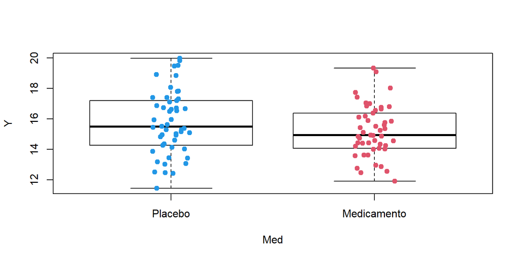

```r
boxplot(Y ~ Med, data = Datos, col = "white", outline=FALSE)
stripchart(Y ~ Med, data = Datos,
           method = "jitter",
           pch = 19,
           col = c(4,2),
           vertical = TRUE,
           add = TRUE)
```

Notamos a primera instancia que el rango intercuartílico del primer boxplot es mayor respecto al segundo, además los bigotes del primero son más largos respecto al segundo. Así, tenemos que hay más variabilidad en los datos de los pacientes que recibieron el placebo respecto a los datos de los pacientes que recibieron el medicamento.

Además de notar cierta simetría en los datos, puede observarse que la mediana de la carga viral $Y$ es mayor en aquellos pacientes que recibieron el placebo versus la mediana de la carga viral de los que recibieron el medicamento. Para fines prácticos puede decirse que en promedio la carga viral es mayor en los pacientes que recibieron el placebo respecto a los que recibieron el medicamento, lo cual representa un argumento a favor de la hipótesis de los investigadores.

2. *Escriba la prueba asociada para argumentar en favor o no de la afirmación de los investigadores. Para esto deberá indicar qué modelo podría usar y cuales son los supuestos de éste*:

Consideraremos el ajuste del modelo

```r
fit <- lm(Y ~ Med, data=Datos)
summary(fit)
```

```
##
## Call:
## lm(formula = Y ~ Med, data = Datos)
##
## Residuals:
##    Min     1Q Median     3Q    Max
## -4.736 -1.132 -0.223  1.381  4.220
##
## Coefficients:
##                Estimate Std. Error t value Pr(>|t|)
## (Intercept)      15.759      0.276   57.13   <2e-16 ***
## MedMedicamento   -0.640      0.390   -1.64      0.1
## ---
## Signif. codes:  0 '***' 0.001 '**' 0.01 '*' 0.05 '.' 0.1 ' ' 1
##
## Residual standard error: 1.9 on 98 degrees of freedom
## Multiple R-squared:  0.0268, Adjusted R-squared:  0.0168
## F-statistic:  2.7 on 1 and 98 DF,  p-value: 0.104
```

del cual se extraen los valores $\hat{\beta_{0}}=15.759$ y $\hat{\beta_{1}}=-0.640$, de donde

- $\mathbb{E}[\textrm{carga viral};\textrm{placebo}]=\mathbb{E}[z=0]=\hat{\beta_{0}}=15.759=\mu_{1}$
- $\mathbb{E}[\textrm{carga viral};\textrm{Medicamento}]=\mathbb{E}[z=1]=\hat{\beta_{0}}+\hat{\beta_{1}}=15.759-0.640=15.119=\mu_{2}$

Se tiene entonces, bajo este ajuste del modelo, que $\mu_{1}>\mu_{2}$. No obstente, el hecho anterior no puede contemplarse si los supuesto del modelo propuesto no se están cumpliendo. Por ello efectuaremos un **análisis de supuestos**:

- **Homocedasticidad**: Comenzamos por visualizar la gráfica que `R` trae por defecto

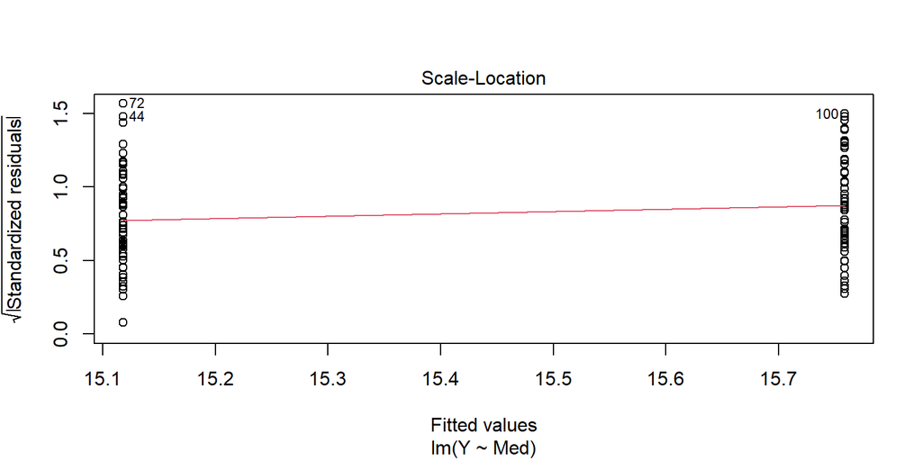

  ```r
  plot(fit,3)
  ```

  observándose una “nube de puntos” muy parecida en ambos casos, lo que representa un indicio a favor de este supuesto. Complementamos realizando dos pruebas de hipótesis

  ```r
  lmtest::bptest(fit)
  ```

  ```
  ##
  ##  studentized Breusch-Pagan test
  ##
  ## data:  fit
  ## BP = 1, df = 1, p-value = 0.2
  ```

  ```r
  car::ncvTest(fit)
  ```

  ```
  ## Non-constant Variance Score Test
  ## Variance formula: ~ fitted.values
  ## Chisquare = 1.2, Df = 1, p = 0.3
  ```

  en ambos casos no se rechaza $H_{0}$, $i.e.$ no hay evidencia suficiente en contra de la homocedasticidad. Finalmente complementamos realizando una *prueba por grupos* donde se contrasta

  $$H_{0}: \sigma_{1}^{2}=\sigma_{2}^{2}\ \ vs \ \ H_{a}: \sigma_{1}^{2}\neq\sigma_{2}^{2}$$

  Usamos

  ```r
  bartlett.test(Y ~ Med, data=Datos)
  ```

  ```
  ##
  ##  Bartlett test of homogeneity of variances
  ##
  ## data:  Y by Med
  ## Bartlett's K-squared = 1, df = 1, p-value = 0.3
  ```

  ```r
  # No paramétrica
  fligner.test(Y ~ Med, data=Datos)
  ```

  ```
  ##
  ##  Fligner-Killeen test of homogeneity of variances
  ##
  ## data:  Y by Med
  ## Fligner-Killeen:med chi-squared = 1, df = 1, p-value = 0.3
  ```

  no rechazándose $H_{0}$ en las pruebas. Por tanto, es plausible asumir que este supuesto es válido dentro del modelo.
- **Normalidad**: Visualizamos inicialmente la Q-Qplot que `R` trae por defecto

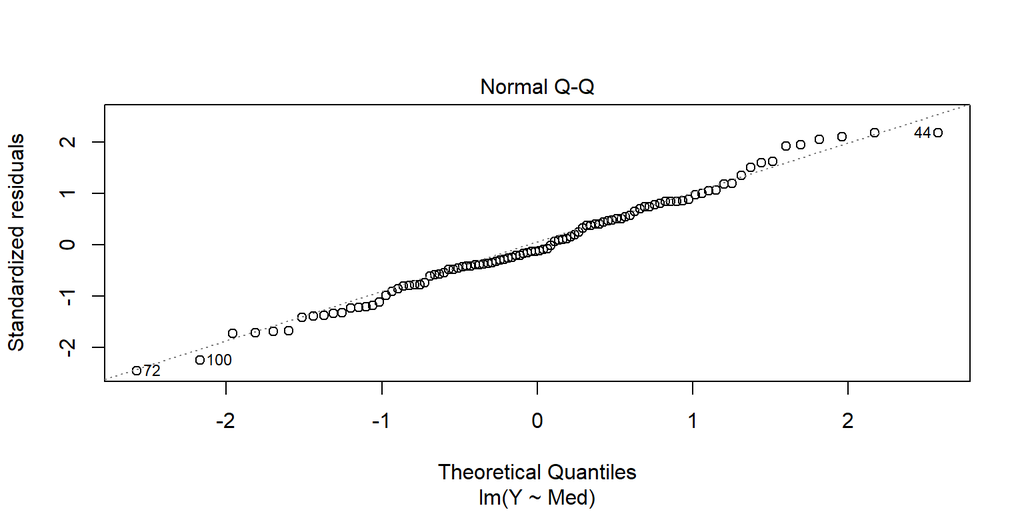

  ```r
  plot(fit,2)
  ```

  observándose un comportamiento muy próximo de los datos a la diagonal, lo cual parece indicar que el supuesto de la normalidad es válido. Complementamos realizando pruebas de hipótesis

  ```r
  # Cálculo de los errores
  Datosfit=augment(fit)

  # Shapiro-Wilk
  shapiro.test(Datosfit$.std.resid)
  ```

  ```
  ##
  ##  Shapiro-Wilk normality test
  ##
  ## data:  Datosfit$.std.resid
  ## W = 1, p-value = 0.6
  ```

  ```r
  # Kolmogorov-Smirnov
  nortest::lillie.test(Datosfit$.std.resid)
  ```

  ```
  ##
  ##  Lilliefors (Kolmogorov-Smirnov) normality test
  ##
  ## data:  Datosfit$.std.resid
  ## D = 0.06, p-value = 0.5
  ```

  ```r
  # Jarque-Bera
  normtest::jb.norm.test(Datosfit$.std.resid)
  ```

  ```
  ##
  ##  Jarque-Bera test for normality
  ##
  ## data:  Datosfit$.std.resid
  ## JB = 0.4, p-value = 0.8
  ```

  en las tres se consigue no rechazar $H_{0}$, $i.e$ es admisible asumir la normalidad de los datos. Finalmente complementamos efectuando la prueba de normalidad por grupos, esto es, realizaremos las tres pruebas anteriores para cada grupo en particular. Resumimos lo obtenido en dichas pruebas:

  ```r
  # Salida que da r de cada una de las pruebas. No mostramos dicha salida pero si
  # consideramos los valores de los p-values obtenidos en estas pruebas
  # en la tabla de líneas abajo

  # ------------------------------------------------------------------------------

  # Placebo:
  # Shapiro-Wilk
  shapiro.test(Datos$Y[Datos$Med=="Placebo"])

  # Kolmogorov-Smirnov
  nortest::lillie.test(Datos$Y[Datos$Med=="Placebo"])

  # Jarque-Bera
  normtest::jb.norm.test(Datos$Y[Datos$Med=="Placebo"])

  # Medicamento
  # Shapiro-Wilk
  shapiro.test(Datos$Y[Datos$Med=="Medicamento"])

  # Kolmogorov-Smirnov
  nortest::lillie.test(Datos$Y[Datos$Med=="Medicamento"])

  # Jarque-Bera
  normtest::jb.norm.test(Datos$Y[Datos$Med=="Medicamento"])
  ```

  ```r
  Prueba <- c("Shapiro-Wilk", "Kolmogorov-Smirnov", "Jarque-Bera")
  Medicamento <- c("p-value=1", "p-value=0.9", "p-value=1")
  Placebo <- c("p-value=0.6", "p-value=0.8", "p-value=0.6")
  c <-list()
  c0 <- rbind(c,Prueba)
  c2 <- rbind(c0,Medicamento)
  c3 <- rbind(c2,Placebo)
  c3
  ```

  ```
  ##             [,1]           [,2]                 [,3]
  ## Prueba      "Shapiro-Wilk" "Kolmogorov-Smirnov" "Jarque-Bera"
  ## Medicamento "p-value=1"    "p-value=0.9"        "p-value=1"
  ## Placebo     "p-value=0.6"  "p-value=0.8"        "p-value=0.6"
  ```

  en todas y cada una no se rechaza $H_{0}$. Tomamos pues como válido el supuesto de la normalidad.

Por inciso anterior sabemos que los supuestos del modelo pueden asumirse como válidos, por ello es posible considerar la prueba

$$H_{0}: \mu_{1}\geq \mu_{2}\ \ \ \ \ vs\ \ \ \ \ H_{a}: \mu_{1}<\mu_{2}$$

que equivale a

$$H_{0}: 0\geq \hat{\beta_{1}}\ \ \ \ \ vs\ \ \ \ \ H_{a}: \hat{\beta_{1}}>0$$

Para ello

```r
# Utilizamos el siguiente paquete
library(multcomp)

#theta = zo*bo + z1*b1
MatZ0Z1=matrix(c(0,1), ncol=2, nrow=1)

# El valor con el que comparamos a b1:
c = 0
```

De tal manera considerando en el modelo $\theta=Z_{0}\beta_{0}+Z_{1}\beta_{1}$ para $Z_{0}=0$ y $Z_{1}=1$ obtenemos que

```r
prueba1=glht(fit, linfct=MatZ0Z1, rhs=c, alternative ="greater")
summary(prueba1)
```

```
##
##   Simultaneous Tests for General Linear Hypotheses
##
## Fit: lm(formula = Y ~ Med, data = Datos)
##
## Linear Hypotheses:
##        Estimate Std. Error t value Pr(>t)
## 1 <= 0    -0.64       0.39   -1.64   0.95
## (Adjusted p values reported -- single-step method)
```

donde no se rechaza $H_{0}$, es decir, no hay suficiente evidencia en contra de que $0\geq \hat{\beta_{1}}$ o equivalentemente $\mu_{1}\geq \mu_{2}$. Completamos realizando dos pruebas donde se contrasta directamente

$$H_{0}: \mu_{1}\geq \mu_{2}\ \ \ \ \ vs\ \ \ \ \ H_{a}: \mu_{1}<\mu_{2}$$

Para ello:

```r
t.test(Y ~ Med, data = Datos, alternative="less",var.equal = TRUE)
```

```
##
##  Two Sample t-test
##
## data:  Y by Med
## t = 2, df = 98, p-value = 0.9
## alternative hypothesis: true difference in means is less than 0
## 95 percent confidence interval:
##  -Inf  1.3
## sample estimates:
##     mean in group Placebo mean in group Medicamento
##                        16                        15
```

```r
t.test(Datos$Y[Datos$Med=="Placebo"], Datos$Y[Datos$Med=="Medicamento"], alternative ="less", var.equal = TRUE)
```

```
##
##  Two Sample t-test
##
## data:  Datos$Y[Datos$Med == "Placebo"] and Datos$Y[Datos$Med == "Medicamento"]
## t = 2, df = 98, p-value = 0.9
## alternative hypothesis: true difference in means is less than 0
## 95 percent confidence interval:
##  -Inf  1.3
## sample estimates:
## mean of x mean of y
##        16        15
```

#### Interpretación:

Se concluye que no hay suficiente evidencia en contra, con una significancia de $\alpha=0.05$, de que en promedio la carga viral es mayor en aquellos pacientes que recibieron el placebo versus los pacientes que recibieron el medicamento.

4. *Suponga ahora que dada la importancia del estudio, le han vuelto a preguntar si los resultados en el inciso III) son contundentes. Para esto, usted ha decidido analizar más el proceso de generación de los datos y ha platicado con los investigadores, logrando que le compartan una nueva variable $Edad$. Realice un análisis descriptivo y/o la visualización de los datos incluyendo esta nueva información. Comente lo que observe analizando si las conclusiones en III) se pueden* **atribuir** *al medicamento*.

Dado que en nuestros datos tenemos los valores `>60` y `<=60` en la columna `Edad`, podemos realizar dos boxplots contrastando la carga viral con los datos de `Edad` , así como hicimos al inicio del análisis descriptivo al contrastar la carga viral con el medicamento y el placebo. Por ende

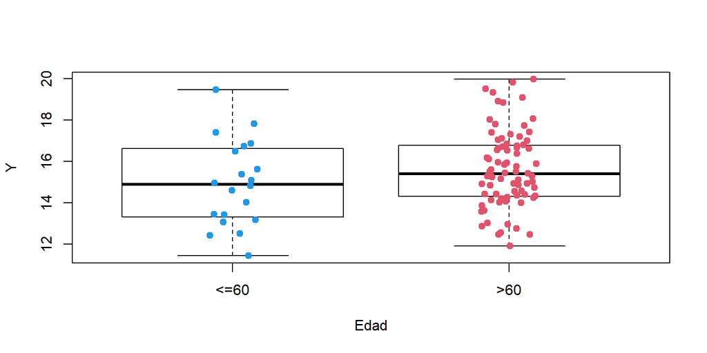

```r
boxplot(Y ~ Edad, data = Datos, col = "white", outline=FALSE)
stripchart(Y ~ Edad, data = Datos,
           method = "jitter",
           pch = 19,
           col = c(4,2),
           vertical = TRUE,
           add = TRUE)
```

donde *parace* ser que hay una relación entre la carga viral y la edad, siendo que la población de más de sesenta años tomada en la muestra de los datos *parece* presenta mayor carga viral respecto a la población de menos de sesenta. Por ello, no podemos tener la certeza de que las conclusiones obtenidas en el inciso anterior se puedan *atribuir* sólo al medicamento, pues el factor edad también juega un papel importante, lo cual se ve reflejado en los boxplots anteriores.

22. *Dependiendo de lo observado en IV) y si considera necesario, repita los incisos II) y III) y concluya.*

Recordemos que la hipótesis de los investigadores es que los pacientes que recibieron el medicamento tienen menor carga viral que los que sólo recibieron placebo. Sin embargo, por lo observado en el inciso anterior parece ser que la carga viral no sólo depende del medicamento sino también de la edad. Para comprobar esto último repetiremos el inciso II) y III) realizando ahora un ajuste del modelo contrastando la carga viral con la edad.

Por consiguiente, al ver los boxplots anteriores se observa cierta simetría en los datos, además de que los rangos intercuartílicos no son muy distintos y los bigotes presentan una longitud similar. Así, parece ser que los supuestos de la normalidad y la homocedasticidad se están cumpliendo.

Para corroborrar procedemos rápidamente al análisis de los supuestos, pero antes es preciso convertir a tipo factor los datos de la columna `edad` y realizar el nuevo ajuste del modelo

```r
# Convertimos la variable Edad a tipo factor
Datos$Edad <- as.factor(Datos$Edad)

# Renombramos por comodidad
levels(Datos$Edad) <- list(Menor_igual_60="<=60", Mayor_60=">60")

# Realizamos el ajuste del modelo con la variable edad
fit2 <-lm(Y ~ Edad, data=Datos)
```

Ahora si:

- **Homocedasticidad:** Observamos la gráfica que `R` trae por defecto

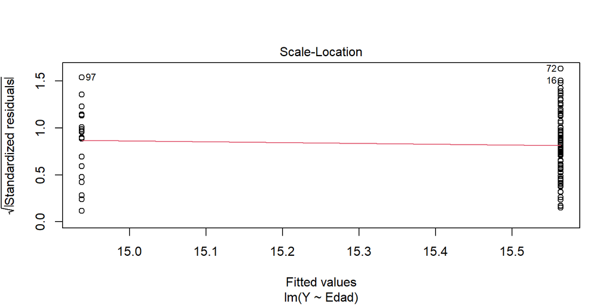

  ```r
  plot(fit2, 3)
  ```

  No se puede ver tan claro el contraste entre el comportamiento de los datos pues el grupo de edad de los menores de 60 años no cuenta con tantos datos como el segundo grupo. Vemos pues algunas pruebas de hipótesis

  ```r
  lmtest::bptest(fit2)
  ```

  ```
  ##
  ##  studentized Breusch-Pagan test
  ##
  ## data:  fit2
  ## BP = 0.09, df = 1, p-value = 0.8
  ```

  ```r
  car::ncvTest(fit2)
  ```

  ```
  ## Non-constant Variance Score Test
  ## Variance formula: ~ fitted.values
  ## Chisquare = 0.086, Df = 1, p = 0.8
  ```

  en ambos casos no se rechaza $H_{0}$ por lo que no hay suficiente evidencia en contra de la homocedasticidad. Veamos también en la prueba por grupos que

  ```r
  # No paramétrica
  fligner.test(Y ~ Med, data=Datos)
  ```

  ```
  ##
  ##  Fligner-Killeen test of homogeneity of variances
  ##
  ## data:  Y by Med
  ## Fligner-Killeen:med chi-squared = 1, df = 1, p-value = 0.3
  ```

  tampoco se rechaza $H_{0}$, por lo que es plausible asumir la igualdad entre varianzas. Se concluye pues que este supuesto es válido.
- **Normalidad**: Observamos la Q-Qplot

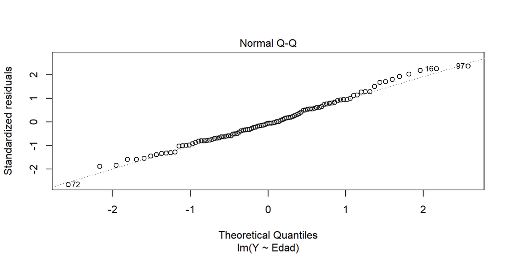

  ```r
  plot(fit2, 2)
  ```

  en la que parece que el supuesto de la normalidad es válido, sin embargo podemos ver varios puntos que resaltan al no estar tan próximos a la recta. Complementamos realizando pruebas de hipótesis.

  ```r
  # Cálculo de los errores
  Datosfit2=augment(fit2)

  # Shapiro-Wilk
  shapiro.test(Datosfit2$.std.resid)
  ```

  ```
  ##
  ##  Shapiro-Wilk normality test
  ##
  ## data:  Datosfit2$.std.resid
  ## W = 1, p-value = 0.7
  ```

  ```r
  # Kolmogorov-Smirnov
  nortest::lillie.test(Datosfit2$.std.resid)
  ```

  ```
  ##
  ##  Lilliefors (Kolmogorov-Smirnov) normality test
  ##
  ## data:  Datosfit2$.std.resid
  ## D = 0.05, p-value = 0.7
  ```

  ```r
  # Jarque-Bera
  normtest::jb.norm.test(Datosfit2$.std.resid)
  ```

  ```
  ##
  ##  Jarque-Bera test for normality
  ##
  ## data:  Datosfit2$.std.resid
  ## JB = 0.7, p-value = 0.7
  ```

  donde no se rechaza $H_{0}$ en las tres pruebas. Hasta el momento todo parece indicar que el supuesto de la normalidad se está dando. Vemos los valores de los *p-values* obtenidos en las pruebas por grupos

  ```r
  # Shapiro-Wilk
  shapiro.test(Datos$Y[Datos$Edad=="Menor_igual_60"])

  # Kolmogorov-Smirnov
  nortest::lillie.test(Datos$Y[Datos$Edad=="Menor_igual_60"])

  # Jarque-Bera
  normtest::jb.norm.test(Datos$Y[Datos$Edad=="Menor_igual_60"])

  # Medicamento
  # Shapiro-Wilk
  shapiro.test(Datos$Y[Datos$Edad=="Mayor_60"])

  # Kolmogorov-Smirnov
  nortest::lillie.test(Datos$Y[Datos$Edad=="Mayor_60"])

  # Jarque-Bera
  normtest::jb.norm.test(Datos$Y[Datos$Edad=="Mayor_60"])
  ```

  ```r
  Prueba2 <- c("Shapiro-Wilk", "Kolmogorov-Smirnov", "Jarque-Bera")
  Menor_igual_60 <- c("p-value=0.9", "p-value=0.7", "p-value=0.6")
  Mayor_60 <- c("p-value=0.7", "p-value=0.6", "p-value=0.8")
  d <-list()
  d0 <- rbind(d,Prueba2)
  d2 <- rbind(d0,Menor_igual_60)
  d3 <- rbind(d2,Mayor_60)
  d3
  ```

  ```
  ##                [,1]           [,2]                 [,3]
  ## Prueba2        "Shapiro-Wilk" "Kolmogorov-Smirnov" "Jarque-Bera"
  ## Menor_igual_60 "p-value=0.9"  "p-value=0.7"        "p-value=0.6"
  ## Mayor_60       "p-value=0.7"  "p-value=0.6"        "p-value=0.8"
  ```

Observemos ahora que

```r
summary(fit2)
```

```
##
## Call:
## lm(formula = Y ~ Edad, data = Datos)
##
## Residuals:
##    Min     1Q Median     3Q    Max
##  -5.18  -1.34  -0.12   1.24   4.53
##
## Coefficients:
##              Estimate Std. Error t value Pr(>|t|)
## (Intercept)    14.938      0.438   34.07   <2e-16 ***
## EdadMayor_60    0.626      0.490    1.28      0.2
## ---
## Signif. codes:  0 '***' 0.001 '**' 0.01 '*' 0.05 '.' 0.1 ' ' 1
##
## Residual standard error: 2 on 98 degrees of freedom
## Multiple R-squared:  0.0164, Adjusted R-squared:  0.00632
## F-statistic: 1.63 on 1 and 98 DF,  p-value: 0.205
```

- $\mathbb{E}[\textrm{Carga viral}; \textrm{Edad menor a 60}]=\mathbb{E}[z=0]=\hat{\beta_{0}}=14.938=\mu_{1}$
- $\mathbb{E}[\textrm{Carga viral}; \textrm{Edad mayor a 60}]=\mathbb{E}[z=1]=\hat{\beta_{0}}+\hat{\beta_{1}}=14.938+0.626=15.564=\mu_{2}$

Consideramos entonces la hipotesis de que la carga viral de la población con edad menor o igual a 60 es menor a la carga viral de la población con edad mayor a 60. De tal suerte es de nuestro interés contrastar

$$H_{0}: \mu_{1}\leq \mu_{2}\ \ \ vs \ \ \ H_{a}: \mu_{1}>\mu_{2}$$

o equivalentemente

$$H_{0}: 0\leq \hat{\beta_{1}}\ \ \ vs \ \ \ H_{a}: 0>\hat{\beta_{1}}$$

Para ello

```r
#theta = zo*bo + z1*b1
Mat2Z0Z1=matrix(c(0,1), ncol=2, nrow=1)

# El valor con el que comparamos a b1:
b = 0
prueba2=glht(fit2, linfct=Mat2Z0Z1, rhs=b, alternative ="less")
summary(prueba2)
```

```
##
##   Simultaneous Tests for General Linear Hypotheses
##
## Fit: lm(formula = Y ~ Edad, data = Datos)
##
## Linear Hypotheses:
##        Estimate Std. Error t value Pr(<t)
## 1 >= 0    0.626      0.490    1.28    0.9
## (Adjusted p values reported -- single-step method)
```

en la que no se rechaza $H_{0}$. O contrastamos directamente

$$H_{0}: \mu_{1}\leq \mu_{2}\ \ \ vs \ \ \ H_{a}: \mu_{1}>\mu_{2}$$

empleando

```r
t.test(Y ~ Edad, data = Datos, alternative ="greater", var.equal = TRUE)
```

```
##
##  Two Sample t-test
##
## data:  Y by Edad
## t = -1, df = 98, p-value = 0.9
## alternative hypothesis: true difference in means is greater than 0
## 95 percent confidence interval:
##  -1.4  Inf
## sample estimates:
## mean in group Menor_igual_60       mean in group Mayor_60
##                           15                           16
```

```r
t.test(Datos$Y[Datos$Edad=="Menor_igual_60"], Datos$Y[Datos$Edad=="Mayor_60"], alternative ="greater", var.equal = TRUE)
```

```
##
##  Two Sample t-test
##
## data:  Datos$Y[Datos$Edad == "Menor_igual_60"] and Datos$Y[Datos$Edad == "Mayor_60"]
## t = -1, df = 98, p-value = 0.9
## alternative hypothesis: true difference in means is greater than 0
## 95 percent confidence interval:
##  -1.4  Inf
## sample estimates:
## mean of x mean of y
##        15        16
```

en las que también no se rechaza $H_{0}$. Consideramos que no hay evidencia suficiente en contra de que $\mu_{1}<\mu_{2}$ por lo que es admisible asumir que la carga viral de la población con edad menor o igual a 60 es menor que la carga viral de la población con edad mayor a 60.

### 6. Uso del modelo de regresión lineal simple

Los $ping\ddot{u}inos$ $Macaroni$ ponen nidadas de dos huevos de tamaño diferente. El peso en gramos de los huevos de 11 nidadas se presenta en la tabla de abajo.

1. Ajuste la recta de regresión del peso del huevo mayor ($y$) en el peso del huevo menor ($x$). Comente sobre el ajuste del modelo, es decir, si parece correcto y si se cumplen los supuestos.
2. Los investigadores tienen la sospecha de que en promedio se puede decir que la diferencia entre el peso mayor y el peso menor es constante (es decir, no depende del peso del huevo menor observado). Usando el modelo en I) realice una prueba de hipótesis para responder la pregunta de los investigadores.
3. Posteriormente se observa el peso de los huevos de una nueva nidada, observándose un peso de 75 y 130 gramos. Usando un intervalo adecuado, comente sobre la sospecha de que la nidada de huevos sí proviene de pinguinos $Macaroni.$

```r
x=c(79, 93, 100, 105, 101, 96, 96, 109, 70, 71, 87)
y=c(133, 148, 164, 171, 165, 159, 162, 170, 127, 133, 148 )

Datos5=data.frame(cbind(x,y))
kable(Datos5)
```

| x | y |
| --- | --- |
| 79 | 133 |
| 93 | 148 |
| 100 | 164 |
| 105 | 171 |
| 101 | 165 |
| 96 | 159 |
| 96 | 162 |
| 109 | 170 |
| 70 | 127 |
| 71 | 133 |
| 87 | 148 |

*–Solución:–*

1. *Ajuste la recta de regresión del peso del huevo mayor ($y$) en el peso del huevo menor ($x$). Comente sobre el ajuste del modelo, es decir, si parece correcto y si se cumplen los supuestos.*

```r
x=c(79, 93, 100, 105, 101, 96, 96, 109, 70, 71, 87)
y=c(133, 148, 164, 171, 165, 159, 162, 170, 127, 133, 148 )

Datos5=data.frame(cbind(x,y))
kable(Datos5)
```

| x | y |
| --- | --- |
| 79 | 133 |
| 93 | 148 |
| 100 | 164 |
| 105 | 171 |
| 101 | 165 |
| 96 | 159 |
| 96 | 162 |
| 109 | 170 |
| 70 | 127 |
| 71 | 133 |
| 87 | 148 |

Comenzamos viendo el scatterplot inicial en el que se ven las relaciones entre el huevo grande y pequeño

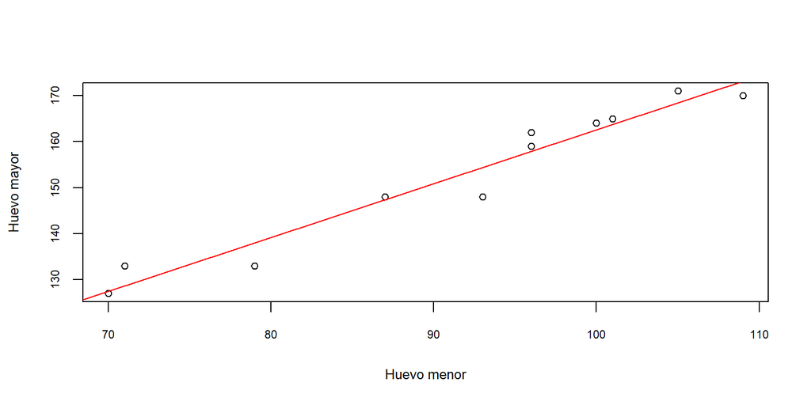

```r
plot(y~x, data=Datos5, xlab = "Huevo menor", ylab = "Huevo mayor", cex=.9, cex.axis=.7, cex.lab=.8)

#Ajuste del modelo de regresión líneal
fit1<-lm(y~x)
abline(fit1, col="red")
```

también

```r
summary(fit1)
```

```
##
## Call:
## lm(formula = y ~ x)
##
## Residuals:
##    Min     1Q Median     3Q    Max
##  -6.43  -1.83   1.06   1.96   4.30
##
## Coefficients:
##             Estimate Std. Error t value Pr(>|t|)
## (Intercept)  45.6742     8.1715    5.59  0.00034 ***
## x             1.1694     0.0884   13.22  3.4e-07 ***
## ---
## Signif. codes:  0 '***' 0.001 '**' 0.01 '*' 0.05 '.' 0.1 ' ' 1
##
## Residual standard error: 3.7 on 9 degrees of freedom
## Multiple R-squared:  0.951,  Adjusted R-squared:  0.946
## F-statistic:  175 on 1 and 9 DF,  p-value: 3.35e-07
```

Con esto vemos que $\beta_{1} = 1.16940$ y $\beta_{0} = 45.67417$.

Podemos ver que si se ajusta una clara linealidad, por lo que parece ser correcto, sin embargo hay que verificar los supuestos:

**Homocedasticidad**

Graficamos las $y_i$ vs los errores estandarizados para comprobar este supuesto

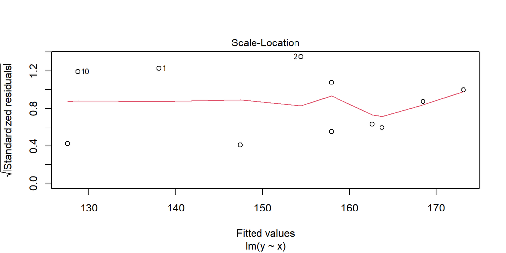

```r
plot(fit1, 3)
```

A partir de esta gráfica no parece haber una diferencia de variabilidad significativa y para poder comprobar esto realizaremos la prueba *Breusch-Pagan* donde se contrasta

$$H_{0}: \textrm{la varianza es constante vs } H_{a}:\textrm{la varianza es una función lineal de } x$$

```r
lmtest::bptest(fit1)
```

```
##
##  studentized Breusch-Pagan test
##
## data:  fit1
## BP = 0.3, df = 1, p-value = 0.6
```

Podemos ver que el $p-value$ es mayor a 0.05por lo que no tenemos suficiente evidencia para rechazar $H_0$ por lo que podemos asumir que la varianza es constante. Por lo tanto, se cumple la homocedasticidad.

**Linealidad**.

Usaremos la grafica propia de `R`

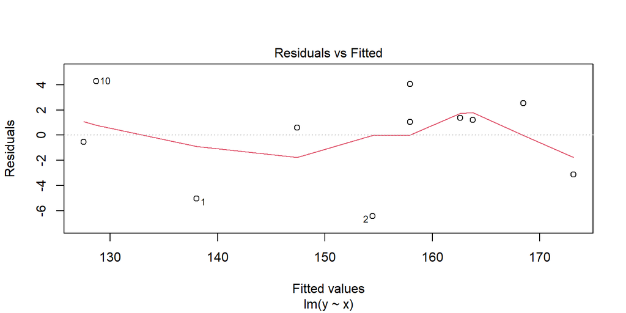

```r
plot(fit1, 1)
```

Con esto podemos ver que no hay un patrón claro, la linea va arriba y abajo de la línea punteada por lo que no podemos asegurar que haya un patrón distinguible, para seguir con este supuesto realizaremos una prueba *boxTidwell* donde se contrasta

$$H_o: \lambda=1 \ \ vs\ \ H_a:\lambda \neq 1.$$

```r
car::boxTidwell(y~x, data = Datos5)
```

```
##  MLE of lambda Score Statistic (z) Pr(>|z|)
##              1                   0      0.7
##
## iterations =  4
```

Podemos ver que el $p-value$ es mayor que 0.05 por lo que podemos concluir que no tenemos suficiente evidencia para rechazar $H_0$, por lo que podemos tomar $\lambda = 1$ y así no tenemos que hacer una transformación *box-Tidwell*. Por lo tanto podemos asegurar que cumple el supuesto de linealidad.

**Normalidad**.

Primero notemos que tenemos 11 observaciones por lo que tenemos una $n$ pequeña, así que hay que usar los errores studentizados. Comencemos por obtener dichos errores

```r
ResSt <- MASS::studres(fit1)
head(ResSt)
```

```
##     1     2     3     4     5     6
## -1.65 -2.16  0.38  0.74  0.34  0.29
```

Ahora usamos el Q-Q plot de una con una $t$ de student con $n-3$ df

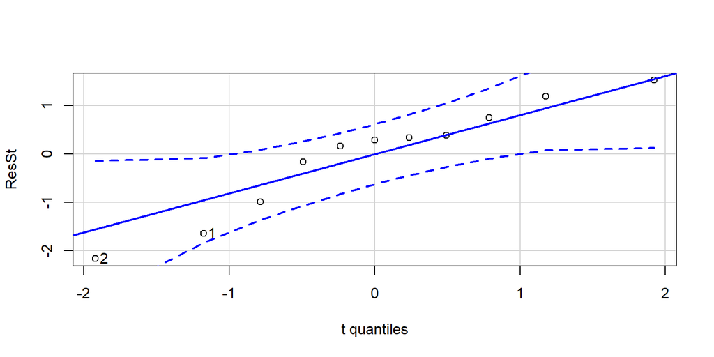

```
## [1] 2 1
```

```r
car::qqPlot(ResSt, dist="t", df=length(ResSt)-3)
```

Con esta grafica podemos darnos una idea de que si se cumple el supuesto, sin embargo, hagamos la prueba de *Kolmogorov-Smirnoff* para estar seguros. Contrastamos

$$\begin{align*}
&H_o: \textrm{los errores studentizados tienen distribución } t \textrm{ de student con } n-3 \textrm{ grados de libertad}\ \ vs\\
&H_a: \textrm{los errores studentizados NO tienen distribución } t \textrm{ de student con } n-3 \textrm{ grados de libertad}
\end{align*}$$

```r
stats::ks.test(ResSt, "pt", length(ResSt)-3)
```

```
##
##  One-sample Kolmogorov-Smirnov test
##
## data:  ResSt
## D = 0.2, p-value = 0.7
## alternative hypothesis: two-sided
```

Podemos ver que el $p-value$ es mayor a 0.05 por lo que no hay suficiente evidencia para rechazar $H_0$,por lo que podemos asumir que los errores tienen una distribución t de student con $n-3$ grados de libertad. Por lo tanto podemos concluir que se cumple el supuesto de normalidad.

**Covarianza cero - Independencia**.

Comenzamos realizando una gráfica sobre el indice de datos

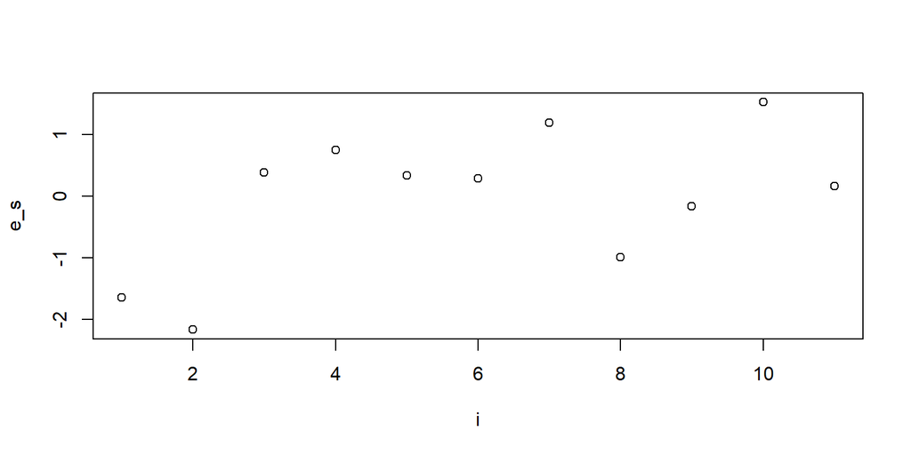

```r
plot(1:length(ResSt), ResSt, xlab = "i", ylab= "e_s"   )
```

Aqui vemos que no se presenta un patrón que rompa con la aleatoriedad. Seguimos con el autocorrelograma de los errores

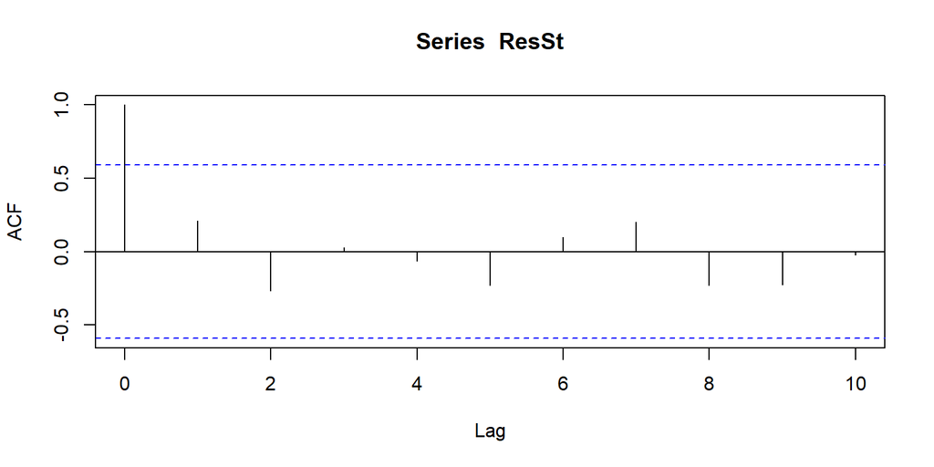

```r
acf(ResSt)
```

Aqui tampoco vemos una relación entre los datos. Para seguir con este supuesto realizamos una prueba de aleatoriedad basada en rachas donde se contrasta

$$\begin{align*}
&H_o: \textrm{las observaciones se pueden considerar aleatorias} \ \ vs\\
&H_a: \textrm{las observaciones NO se pueden considerar aleatorias}
\end{align*}$$

```r
randtests::runs.test(ResSt)
```

```
##
##  Runs Test
##
## data:  ResSt
## statistic = -0.7, runs = 5, n1 = 5, n2 = 5, n = 10, p-value = 0.5
## alternative hypothesis: nonrandomness
```

Aqui vemos que el p-value es mayor que 5% por lo que podemos afirmar que no contamos con suficiente evidencia para rechazar $H_0$ por lo que podemos asumir que las observaciones son aleatorias. Por lo tanto se cumple el supuesto de covarianza cero - independencia.

Finalmente analicemos que sucede con $R^{2}$. Con el `summary` vemos que $R^{2}$ tiene un valor de 0.9511 por lo que el huevo menor explica en un $95.11\%$ el peso del huevo más grande.

Finalmente realizamosla siguiente prueba de hipotesis

$$H_0 : \beta_{1} = 0\ \ vs\ \ H_a : \beta_{1} \neq 0$$

Como vemos poder en el `summary` el $p-value es menor que$ $5\%$ por lo tanto podemos afirmar que tenemos evidencia suficiente para rechazar $H_0$ y por lo tanto la variable $y$ si se puede modelar a partir de $x$. Con esto podemos ver que se cumplen los 4 supuestos ycon las conclusiones de que se puede usar a $x$ podemos modelar a y podemos concluir que el modelo es correcto.

*ii. Los investigadores tienen la sospecha de que en promedio se puede decir que la diferencia entre el peso mayor y el peso menor es constante (es decir, no depende del peso del huevo menor observado). Usando el modelo en I) realice una prueba de hipótesis para responder la pregunta de los investigadores.*

Como ya verificamos el modelo es apropiado por lo que podemos modelar la esperanza de $y$ como $E[y] = \beta_0 + \beta_1 x$. Como queremos que la diferencia entre el peso mayor y el menor sea constante podemos verlo como: $E[y - x] = c$.

Recordando que modelando la $E[y]$ en realidad estamos modelando $E[y | x]$, por lo que tenemos

$$\begin{align*}
\Rightarrow \ \ & E[(y | x) - x] = c\\
\Rightarrow \ \ & E[y | x] - x = c\\
\Rightarrow \ \ & B0 + B1 x - x = c
\end{align*}$$

Con lo que buscamos que esta ultima expresion no dependa de $x$, por lo que queremos que $\beta_{1} x - x = 0$, es decir que $\beta_1 = 1$ De tal manera haremos una prueba de hipotesis para contrastar

$$H_o: \beta_1 = 1\ \ vs\ \ H_a: \beta_1 \neq 1$$

```r
z <- y - x
fit2 <- lm(z ~ x)
summary(fit2)
```

```
##
## Call:
## lm(formula = z ~ x)
##
## Residuals:
##    Min     1Q Median     3Q    Max
##  -6.43  -1.83   1.06   1.96   4.30
##
## Coefficients:
##             Estimate Std. Error t value Pr(>|t|)
## (Intercept)  45.6742     8.1715    5.59  0.00034 ***
## x             0.1694     0.0884    1.92  0.08765 .
## ---
## Signif. codes:  0 '***' 0.001 '**' 0.01 '*' 0.05 '.' 0.1 ' ' 1
##
## Residual standard error: 3.7 on 9 degrees of freedom
## Multiple R-squared:  0.29,   Adjusted R-squared:  0.211
## F-statistic: 3.67 on 1 and 9 DF,  p-value: 0.0877
```

Con este summary podemos ver que p-value es mayor que 0.05 por lo que no hay evidencia suficiente para rechazar $H_0$ por lo que tenemos que $\beta_1$ es 0, con esto podemos decir que para modelar $z$ no es necesario usar $x$, por lo que esta diferencia no depende de $x$ y por ende podríamos decir que hay evidencia para afirmar que la diferencia entre los pesos de los huevos es constante.

*iii. Posteriormente se observa el peso de los huevos de una nueva nidada, observándose un peso de 75 y 130 gramos. Usando un intervalo adecuado, comente sobre la sospecha de que la nidada de huevos sí proviene de pinguinos $Macaroni.$*

Hay que realizar una predicción

```r
new<-data.frame(x=c(75))
pred<-predict(fit1,new,interval="prediction",level=.95)
head(pred)
```

```
##   fit lwr upr
## 1 133 124 143
```

### 7.

Considere los datos en la base *infectionrisk.txt* y las variables: $y =$ riesgo de infección (InfctRsk) y $x =$ promedio de estancia en un hospital (Stay), sólo los datos de las regiones 1 y 2 (Region==1 | Region==2). Después de una investigación minuciosa, los responsables de la base de datos indican que todos los valores parecen reflejar la esperanza del riesgo de infección para los diferentes valores de $x$, es decir, que no se debe eliminar ninguna observación.

1. Ajustar un modelo de regresión lineal simple. Verificar los supuestos a partir de este modelo. Deberá indicar para cada supuesto qué gráfica o prueba sirve para argumentar el cumplimiento o no del supuesto.
2. En caso de que alguno de los supuestos no se satisfaga en I), realizar modificaciones a las variables para encontrar un modelo en donde sí se satisfagan los supuestos.
   1. Para transformar la variable Y, probar con transformaciones Box-Cox
   2. Para transformar la variable X, probar con transformaciones Box-Tidwell u otras conocidas como log() o exp().

Al finalizar, deberá indicar el modelo de regresión lineal simple que se ajustará, haciendo explícito qué variables fueron transformadas y cómo. También deberá indicar para cada supuesto del modelo de regresión qué gráfica o prueba sirve para argumentar su cumplimiento.

3. En una misma gráfica incluir los puntos en escala original, la recta de regresión del modelo en I) y la curva del modelo en II).
4. Interpretar $R^2$ y la prueba anova del modelo en II).
5. Con el modelo final ayude a un investigador a argumentar a favor o en contra de la hipótesis: “El riesgo de infección de los pacientes cuando tienen una estancia de 10 es en general mayor a 3”.

*–Solución–:*

*i. Ajustar un modelo de regresión lineal simple. Verificar los supuestos a partir de este modelo. Deberá indicar para cada supuesto qué gráfica o prueba sirve para argumentar el cumplimiento o no del supuesto.*

Cargamos

```r
library(dplyr)
library(ALSM)
library(broom)
library(SciViews)
```

Comenzamos por cargar los datos y realizar el filtro de las regiones

```r
# Cargamos los datos
datos <- read.table("infectionrisk.txt", TRUE)

# Realizamos el filtro de los datos
datos1 <- datos %>% filter (Region %in% c(1,2))

# definimos dos nuevas variables
y <- datos1$InfctRsk
x <- datos1$Stay
```

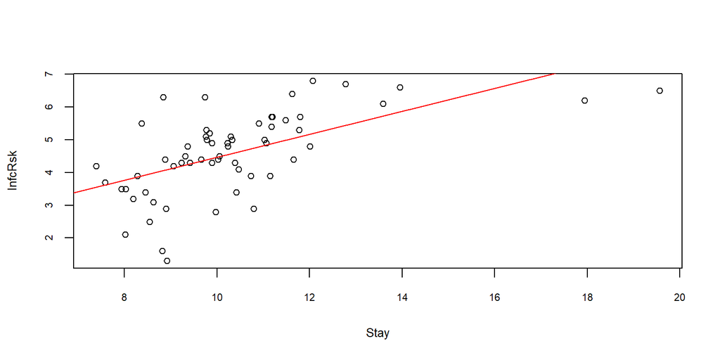

```r
plot(y~x, data=datos1, xlab = "Stay", ylab = "InfcRsk", cex=.9, cex.axis=.7, cex.lab=.8)
fit7<-lm(y~x) #Ajuste del modelo de regresión líneal
abline(fit7, col="red")
```

y

```r
summary(fit7)
```

```
##
## Call:
## lm(formula = y ~ x)
##
## Residuals:
##    Min     1Q Median     3Q    Max
## -2.784 -0.554  0.097  0.614  2.244
##
## Coefficients:
##             Estimate Std. Error t value Pr(>|t|)
## (Intercept)   0.9468     0.6571    1.44     0.15
## x             0.3517     0.0623    5.65  5.1e-07 ***
## ---
## Signif. codes:  0 '***' 0.001 '**' 0.01 '*' 0.05 '.' 0.1 ' ' 1
##
## Residual standard error: 1 on 58 degrees of freedom
## Multiple R-squared:  0.355,  Adjusted R-squared:  0.344
## F-statistic: 31.9 on 1 and 58 DF,  p-value: 5.14e-07
```

Con esto vemos que $\beta_1 = 0.35172$ y $\beta_0 = 0.94680$. Podemos ver que si se ajusta una clara linealidad, por lo que parece ser correcto, sin embargo hay que verificar los supuestos.

**Homocedasticidad.**

Graficamos las $y_i$ vs los errores estandarizados para comprobar este supuesto

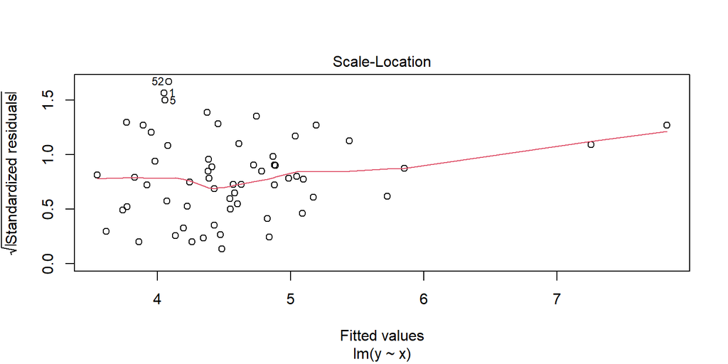

```r
plot(fit7, 3)
```

A partir de esta gráfica no parece haber una diferencia de variabilidad significativa y para poder comprobar esto realizaremos la prueba *Breusch-Pagan*, donde se contrasta

$$H_0: \textrm{la varianza es constante}\ \ vs \ \ H_a: \textrm{la varianza es una función lineal de } x.$$

```r
lmtest::bptest(fit7)
```

```
##
##  studentized Breusch-Pagan test
##
## data:  fit7
## BP = 0.2, df = 1, p-value = 0.7
```

Podemos ver que el $p-value$ es mayor a 0.05 por lo que no tenemos suficiente evidencia para rechazar $H_0$ por lo que podemos asumir que la varianza es constante. Por lo tanto, se cumple la homocedasticidad.

**Linealidad.**

Usaremos la grafica propia de `R`

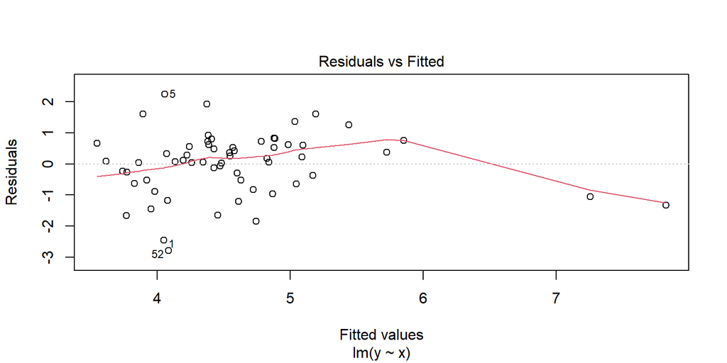

```r
plot(fit7, 1)
```

Con esto podemos ver que no hay un patrón claro, la línea va arriba y abajo de la línea punteada por lo que no podemos asegurar que haya un patrón distinguible, para seguir con este supuesto realizaremos una prueba *boxTidwell* donde se contrasta

$$H_o: \lambda=1 \ \ vs \ \ H_a: \lambda \neq 1.$$

```r
car::boxTidwell(y~x, data = datos1)
```

```
##  MLE of lambda Score Statistic (z) Pr(>|z|)
##             -1                  -2     0.02 *
## ---
## Signif. codes:  0 '***' 0.001 '**' 0.01 '*' 0.05 '.' 0.1 ' ' 1
##
## iterations =  7
```

**Normalidad.**

Primero notemos que tenemos 60 observaciones por lo que tenemos una $n$ grande así que comenzamos con usar el Q-Q plot que `R` trae por defecto.

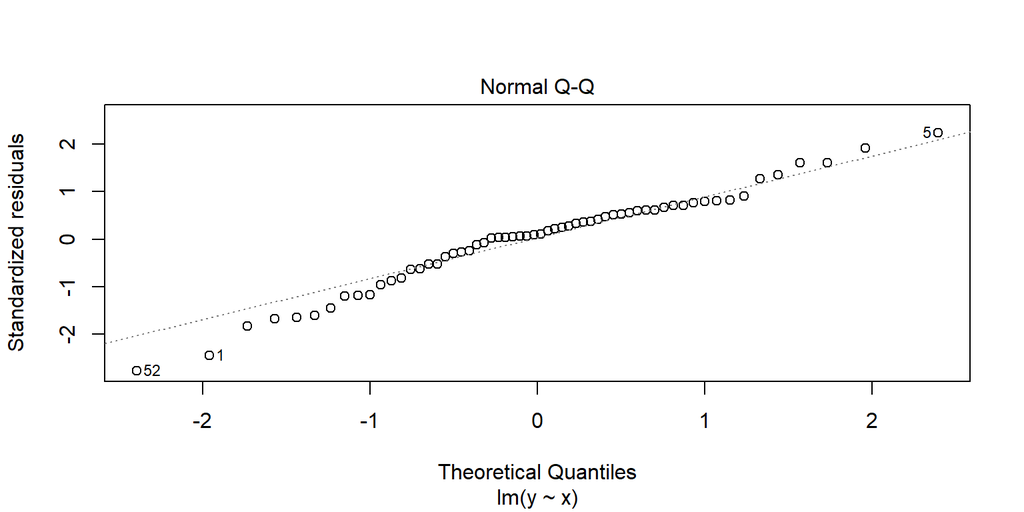

```r
plot(fit7, 2)
```

Con esta grafica podemos darnos una idea de que si se cumple el supuesto, sin embargo, hagamos la prueba de *Jarque-Bera* para estar seguros, donde se contrasta

$$\begin{align*}
& H_0 : e_{st_1},\ldots, e_{st_n} \textrm{ provienen de una Normal vs}\\
& H_a : e_{st_1},\ldots, e_{st_n} \textrm{ NO provienen de una Normal}
\end{align*}$$

```r
datosfit <- augment(fit7)
normtest::jb.norm.test(datosfit$.std.resid)
```

```
##
##  Jarque-Bera test for normality
##
## data:  datosfit$.std.resid
## JB = 2, p-value = 0.2
```

Podemos ver que el p-value es mayor a 0.05 por lo que no hay suficiente evidencia para rechazar $H_0$, por lo que podemos asumir que los errores provienen de una normal permitiendonos concluir que se cumple el supuesto de normalidad.

**Covarianza cero - Independencia**.

Comenzamos realizando una gráfica sobre el indice de datos

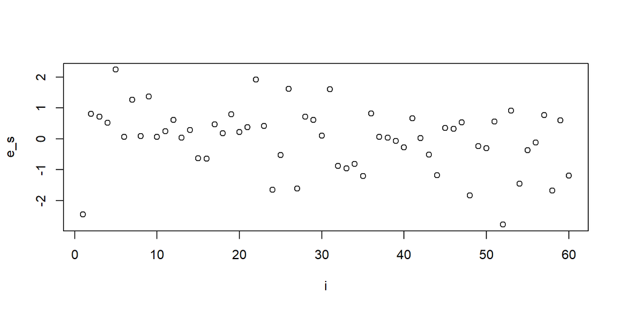

```r
plot(1:length(datosfit$.std.resid), datosfit$.std.resid,
     xlab = "i", ylab= "e_s")
```

Aqui vemos que no se presenta un patrón que rompa con la aleatoriedad. Seguimos con el autocorrelograma de los errores

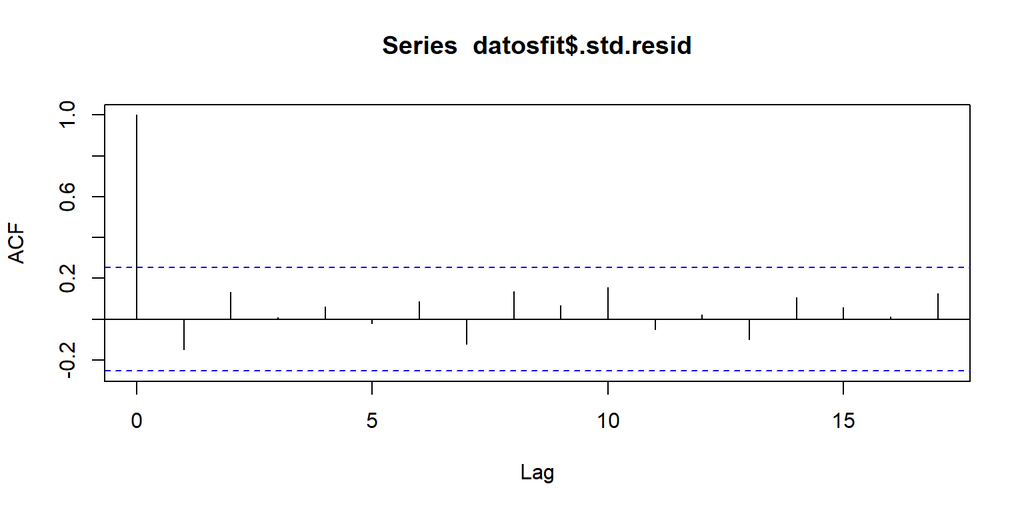

```r
acf(datosfit$.std.resid)
```

Aqui tampoco vemos una relación entre los datos. Para seguir con este supuesto realizamos una prueba de aleatoriedad basada en rachas donde se contrasta

$$\begin{align*}
& H_0 : \textrm{ las observaciones se pueden considerar aleatorias vs}\\
& H_a : \textrm{ las observaciones NO se pueden considerar aleatorias}
\end{align*}$$

```r
randtests::runs.test(datosfit$.std.resid)
```

```
##
##  Runs Test
##
## data:  datosfit$.std.resid
## statistic = 0, runs = 31, n1 = 30, n2 = 30, n = 60, p-value = 1
## alternative hypothesis: nonrandomness
```

Aqui vemos que el p-value es mayor que $5\%$ por lo que podemos afirmar que no contamos con suficiente evidencia para rechazar $H_0$ por lo que podemos asumir que las observaciones son aleatorias. Por lo tanto se cumple el supuesto de covarianza cero - independencia.

Finalmente analicemos que sucede con $R^{2}$. Con el `summary` vemos que $R^{2}$ tiene un valor de 0.3549 por lo que el tiempo de espera explica en un $35.49\%$ el riesgo de infección. Finalmente realizamosla siguiente prueba de hipotesis:

$$H_0 : \beta1 = 0\ \ vs \ \ H_a : \beta1 \neq 0$$

Como vemos poder en el summary el p-value es menor que $5\%$ Por lo tanto podemos afirmar que tenemos evidencia suficiente para rechazar $H_0$ y por lo tanto la variable y si se puede modelar a partir de $x$.

Con esto podemos ver que solo hay que realizar transformaciones para que se cumpla el supuesto de linealidad, para así poder mejorar nuestro modelo.

*ii. En caso de que alguno de los supuestos no se satisfaga en I), realizar modificaciones a las variables para encontrar un modelo en donde sí se satisfagan los supuestos.* *a. Para transformar la variable Y, probar con transformaciones Box-Cox* *a. Para transformar la variable X, probar con transformaciones Box-Tidwell u* *otras conocidas como log() o exp().*

Antes de checar la transformación *box-Tidwell* vamos a probar con la transformación $ln$. Primero probaremos para la linealidad que fue el supuesto que no se cumplía.

Comenzamos con la gráfica que `R` trae por defecto

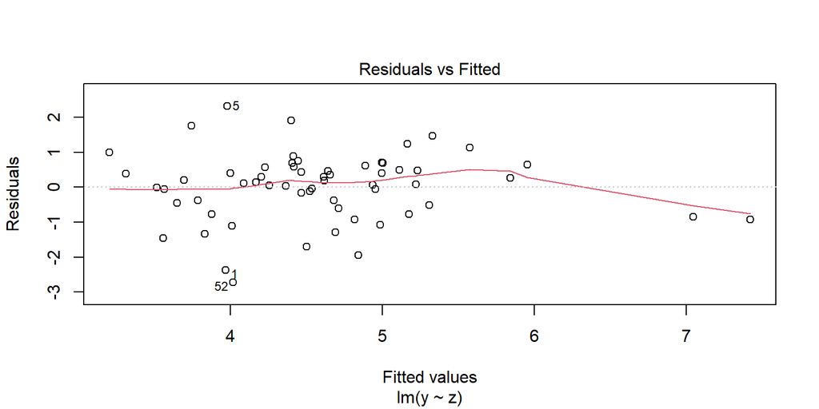

```r
# Ajuste del modelo con la x transformada
z <- ln(x)
fit_tr <- lm(y ~ z, data = datos1)

# Gráfica
plot(fit_tr,1)
```

en el cual no se ve un patrón aparente. Complementamos realizando una prueba de hipótesis

```r
car::boxTidwell(y~z, data = datos1)
```

```
##  MLE of lambda Score Statistic (z) Pr(>|z|)
##             -1                  -1      0.3
##
## iterations =  7
```

Con esto podemos ver que el $p-value$ ya es mayor a 0.05 por lo que con esta transformación se cumple la linealidad. Con esto podríamos afirmar que el modelo que queremos ajustar es `y ~ ln(x)`. Este modelo se encontró transformando la variable $x$ simplemente aplicando el logaritmo natural. Ahora veamos rapidamente los demás supuestos para este nuevo modelo.

**Homocedasticidad.**

Vemos la gráfica que `R` trae por defecto para analizar este supuesto y complementemos haciendo la prueba de *Breusch-Pagan*

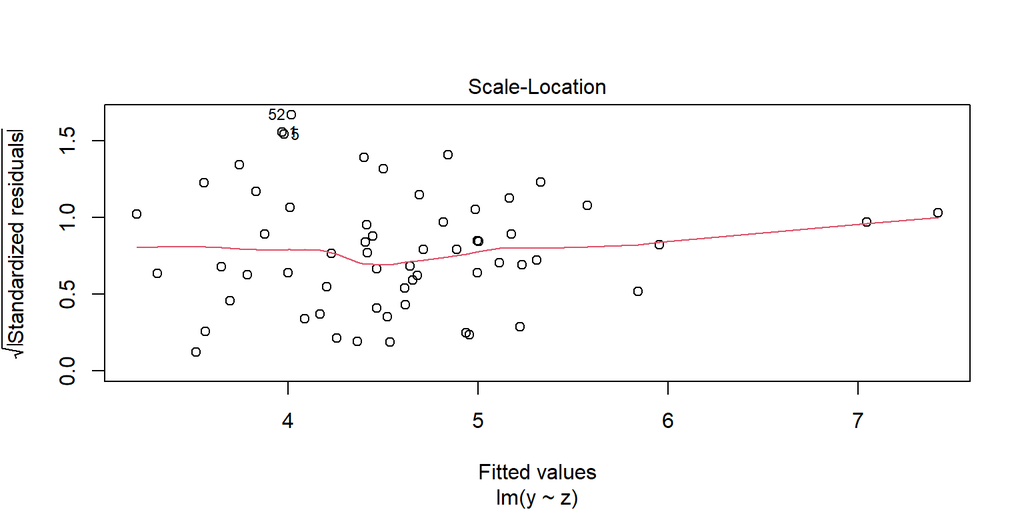

```r
plot(fit_tr,3)
```

```r
lmtest::bptest(fit_tr)
```

```
##
##  studentized Breusch-Pagan test
##
## data:  fit_tr
## BP = 1, df = 1, p-value = 0.3
```

donde en la gráfica puede apreciarse cierta nube de puntos de la misma longitud y donde el $p-value$ es mayor a 0.05. Por ende podemos afirmar que se cumple la homocedasticidad.

**Normalidad.**

Utilizando la Q-Qplot y la prueba de *Jarque-Bera*

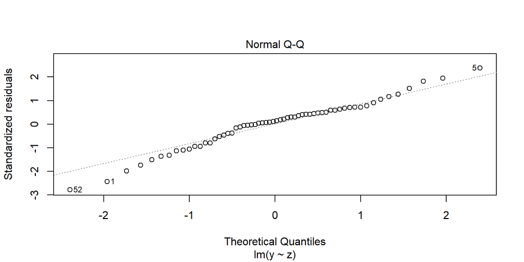

```r
plot(fit_tr,2)
```

```r
datosfit_tr <- augment(fit_tr)
normtest::jb.norm.test(datosfit_tr$.std.resid)
```

```
##
##  Jarque-Bera test for normality
##
## data:  datosfit_tr$.std.resid
## JB = 2, p-value = 0.2
```

Vemos que hay varios puntos que salen de la diagonal pero también podemos ver que el $p-value$ es mayor a 0.05 por lo que podemos afirmar que se cumple el supuesto de normalidad.

**Covarianza cero - Independencia.**

Realizamos la gráfica sobre el índice de los datos y el autocorrelograma

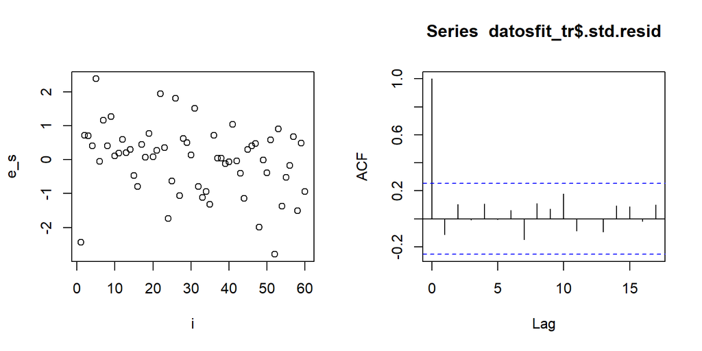

```r
par(mfrow=c(1,2))
plot(1:length(datosfit_tr$.std.resid), datosfit_tr$.std.resid,
     xlab = "i", ylab= "e_s")
acf(datosfit_tr$.std.resid)
```

en donde en la gráfica de los índice no puede observarse un patrón aparente y en el autocorrelograma tampoco se ve una relación entre los datos. Complementamos realizando una prueba basada en rachas

```r
randtests::runs.test(datosfit_tr$.std.resid)
```

```
##
##  Runs Test
##
## data:  datosfit_tr$.std.resid
## statistic = 0, runs = 31, n1 = 30, n2 = 30, n = 60, p-value = 1
## alternative hypothesis: nonrandomness
```

Podemos ver que el p-value es mayor a 0.05 por lo que podemos decir que se cumple el supuesto de aleatoriedad.

*iii. En una misma gráfica incluir los puntos en escala original, la recta de regresión del modelo en I) y la curva del modelo en II).*

Para ello

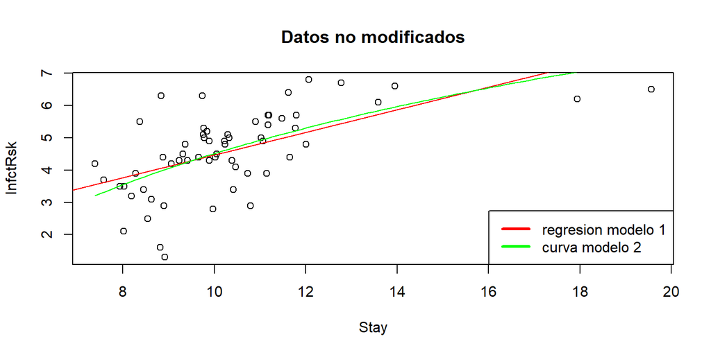

```r
plot(x,y, main = "Datos no modificados", xlab="Stay", ylab = "InfctRsk")
abline(fit7, col= "red", )

f<- function(x)
    (-5.4575 + 4.3305*ln(x))

curve(f, from=min(x), to = max(x), col="green", add=T)
legend("bottomright", legend = c("regresion modelo 1", "curva modelo 2"),
       lwd = 3, col = c("red", "green"))
```

donde la función que describe la curva del modelo 2 se obtuvo de graficar la relación $\hat{y}=\hat{\beta_{0}}+\hat{\beta_1}x=-5.4575 + 4.3305 \cdot ln(x)$.

*iv. Interpretar $R^2$ y la prueba anova del modelo en II).*

Consideramos primero la información en el `summary`

```r
summary(fit_tr)
```

```
##
## Call:
## lm(formula = y ~ z, data = datos1)
##
## Residuals:
##    Min     1Q Median     3Q    Max
## -2.719 -0.533  0.123  0.575  2.320
##
## Coefficients:
##             Estimate Std. Error t value Pr(>|t|)
## (Intercept)   -5.457      1.653   -3.30   0.0016 **
## z              4.330      0.711    6.09  9.5e-08 ***
## ---
## Signif. codes:  0 '***' 0.001 '**' 0.01 '*' 0.05 '.' 0.1 ' ' 1
##
## Residual standard error: 0.99 on 58 degrees of freedom
## Multiple R-squared:  0.39,   Adjusted R-squared:  0.38
## F-statistic: 37.1 on 1 and 58 DF,  p-value: 9.53e-08
```

Aqui podemos ver que $R^2$ es de $0.3904$, que nos indica que los días de estancia influyen en un $39\%$ en el riesgo de infección. Después para la prueba anova

```r
anova(fit_tr)
```

|  | Df | Sum Sq | Mean Sq | F value | Pr(>F) |
| --- | --- | --- | --- | --- | --- |
| z | 1 | 36 | 36.20 | 37 | 9.5e-08 |
| Residuals | 58 | 57 | 0.97 | NA | NA |

ahora contrastemos

$$H_0 : \beta1 = 0 \ \ vs \ \ H_a : \beta_1 \neq 0$$

Se puede observar que el $p-value$ es menor a 0.05 por lo que podemos afirmar que tenemos suficiente evidencia para rechazar $H_0$, por lo que podemos decir que $x$ si sirve para modelar a $y$. Es decir, tiene sentido considerar $\hat{y_i}=\hat{\beta_{0}}+\hat{\beta_{1}}x_{i}$.

*v. Con el modelo final ayude a un investigador a argumentar a favor o en contra de la hipótesis: “El riesgo de infección de los pacientes cuando tienen una estancia de 10 es en general mayor a 3”.*

Para ello utilizaremos un intervalo de predicción:

```r
new2<-data.frame(z=c(ln(10)))
pred2<-predict(fit_tr,new2,interval="prediction",level=.95)
head(pred2)
```

```
##   fit lwr upr
## 1 4.5 2.5 6.5
```